花了一點時間把我覺得重要的東西整理了一下

如果有什麼問題的話歡迎寄mail問我 dingdang827@gmail.com

# 變數

每個object有相應的type

常見的有

- int 整數
- float 浮點數: 也就是小數
- bool 布林值: 用於邏輯判斷
- string 字串
- None 無

```python
a = 5   #int 整數
b = 3.0 #float 浮點數
c = 'abc' #string 字串
d = True
e = None
```

```python
print("a的type:",type(a))
print("b的type:",type(b))
print("c的type:",type(c))
print("d的type:",type(d))
print("e的type:",type(e))
```

```
a的type: <class 'int'>
b的type: <class 'float'>
c的type: <class 'str'>
d的type: <class 'bool'>
e的type: <class 'NoneType'>
```

## 數值的運算

- +,-,*,/ 加減乘除 這個跟你想的一樣
- % 取餘數
- // 整除，這種除法只會有商整數的部分，而只有一個/的除法會將小數除出來
- ** 這是次方

```python
print("加減乘除就跟你們想的一樣，比較特別的是")
print("3/2 = ",3/2) #除
print("3//2 = ",3//2) #整除
print("3%2 = ",3%2) #取餘數
print("2**3 = ",2**3) #次方
```

```
加減乘除就跟你們想的一樣，比較特別的是
3/2 =  1.5
3//2 =  1
3%2 =  1
2**3 =  8
```

## 字串的運算

- a+b 就是把a跟b連接起來
- a*3 乘法就是3個a連接起來

```python
s = 'Vivian'
s2 = ' likes python'
```

```python
s*3
```

```
'VivianVivianVivian'
```

```python
s+s
```

```
'VivianVivian'
```

```python
s+s2
```

```
'Vivian likes python'
```

# Structure type:

- tuple (1,2,3) 用小括號
- list [1,2,3] 用中括號(這個比較常用)
  - tuple跟list主要差別在tuple是immutable 意思是裡面的東西不能改變 下面會有例子
  - list是 mutable隨時可以改變裡面的值
- dictionary {1:'a',2:'b',3:'c'} 用大括號 (期中考不會出現) **另外以上三個結構裡面的元素型態都可以隨意放**
- range 這個目前會用到都是為了for迴圈，這個講for的時候再介紹

```python
t = (1,2,3) #tuple
l = [1,2,3] #list
li = ['a',2,5.0,None] #可以隨便放的意思是這樣不同型態可以混合
li
```

```
['a', 2, 5.0, None]
```

```python
#直接改變tuple內的值會有錯誤
t[0]=2
```

```
---------------------------------------------------------------------------
TypeError                                 Traceback (most recent call last)
<ipython-input-9-a11616e5982d> in <module>
      1 #直接改變tuple內的值會有錯誤
----> 2 t[0]=2

TypeError: 'tuple' object does not support item assignment
```

```python
#但List可以直接改下面的值
l[0]=2
l
```

```
[2, 2, 3]
```

### 常見的list method(補充)

[figure not shown]

通常內建的object都有許多method可以使用

使用方法就是將物件後面加.method名稱

下面以list.sort()當作範例 其他就自己玩玩看唄

```python
l = [3,2,1]
l.sort()#將l做排序
l
```

```
[1, 2, 3]
```

**dictionary** 這個結構類似於mapping 也就是將一個值對應到某個值

不過老師說這次沒有考這個

dictionary內的元素是照這個格式{key:value}

當我們輸入d[key]時 會將對應到的value顯示出來

以下是範例

```python
d = {0:'a',1:'b',2:'c','good':4}
display(d[0])
display(d['good'])
#這個display不用管他 使用它只是讓同一格輸入可以顯示出多個output
```

```
'a'
```

```
4
```

### Slice

這個東西我覺得是python比其他程式語言好用的優點之一

它的功能主要是擷取資料的一部分

只要是structure type的物件都可以使用

格式是 資料[起始點:終止點:間隔] 除了第一個一定要打(只打第一個其實就是index)其他都是選填

程式語言中 大部分都是從0開始數

另外在python中也可以從最後一個數回來，位置是從-1,-2 數回來

直接看範例比較快(以list為例)

```python
l = [1,2,3,4,5,6,7,8,9,10]
print("l[0]的值為:",l[0])
print("l[3]的值為:",l[3])
print("l[-1]的值為:",l[-1])
print("l[-3]的值為:",l[-3])
print("l[0:3]的值為:",l[0:3])#取0 1 2 終止點是不拿的
print("l[::2]的值為:",l[::2])#當不輸入前面的值的時候默認是全選 這個是取每隔2個的元素
print("l[::-1]的值為:",l[::-1])#從後面數回來
#其他就自己玩一下吧
```

```
l[0]的值為: 1
l[3]的值為: 4
l[-1]的值為: 10
l[-3]的值為: 8
l[0:3]的值為: [1, 2, 3]
l[::2]的值為: [1, 3, 5, 7, 9]
l[::-1]的值為: [10, 9, 8, 7, 6, 5, 4, 3, 2, 1]
```

## 程式流程控制

我好像只看到老師用到for迴圈 所以只講if,for和list comprehension

### if 的用法

在程式中if是很重要的東西，因為你的程式要能夠因應不同的情況做不同事情

這時候我們就需要有個判斷式來決定說程式怎麼執行

那if的格式是這個樣子

```
if (條件):
    程式碼
elif(條件):
    程式碼
else:
    程式碼
```

也就是當條件成立(= True)時我們執行if之下的程式碼然後結束，條件不成立(=False)時判斷下一格內的條件

整個區塊只會有一個程式碼被執行到，另外elif跟else是選填

**那重要的地方是if後面的程式碼需要縮排電腦才知道那些是在if裡面的程式**

下面我們先看幾個條件判斷

```python
1 == 2 #等於 1等於2 => 錯的
#注意這和賦予變數值的=不一樣 這是兩個等號
```

```
False
```

```python
1 != 2 #不等於 1不等於2 =>對的
```

```
True
```

```python
type(1) is int #1的type是int => 對的 True
```

```
True
```

```python
type("abc") is not str #'abc'的type 不是 str =>錯的 False
```

```
False
```

**is 和 == 有差異 有興趣可以去google**

### if 的範例

```python
grade = 75
#--------------------------------------
if grade >= 80:#會先判斷if內的條件，如果成立就執行prinf("good")然後結束，不成立就判斷elif內grade是否大於60
    print("Good!")
elif grade >= 60:#可以有多個，當上面的條件不成立就會判斷它的條件
    print("Pass!")
else:#else是當上面的判斷都不成立時才會執行
    print("Fail!")
#--------------------------------------
#整個區塊內只會有一格被執行到
```

```
Pass!
```

### Range

先講range這個結構

它的用法跟上面的slice差不多

range(起始位置:終止位置:間隔)

不過你直接印出來是顯示不出來裡面所有元素的

所以我們要看裡面的值可以將它轉成list(但使用它的時候並不需要轉化 這個只是讓我們看裡面怎麼運作)

```python
display(range(5))#直接印出來它只會告訴你起始值和終止值
display(list(range(5)))#將它轉成list就可以看裡面的值了
```

```
range(0, 5)
```

```
[0, 1, 2, 3, 4]
```

```python
print("range(5) = ",list(range(5)))
print("range(3,5) = ",list(range(3,5)))
print("range(0,10,2) = ",list(range(0,10,2)))
#當然也可以倒著數 但是起點和終點就要特別注意了
print("range(-1,-10,-1) = ",list(range(-1,-10,-1)))
```

```
range(5) =  [0, 1, 2, 3, 4]
range(3,5) =  [3, 4]
range(0,10,2) =  [0, 2, 4, 6, 8]
range(-1,-10,-1) =  [-1, -2, -3, -4, -5, -6, -7, -8, -9]
```

### for的用法

包在迴圈內的程式要縮排 電腦才看得懂這是要迴圈執行的程式碼

```
for 變數 in 結構:
    迴圈的程式
```

變數的名稱我們通常沒特別意義都從i j k...開始用

下面有幾個範例幫助理解

```python
print(0,end=',')
print(1,end=',')
print(2,end=',')
print(3,end=',')
print(4,end=',')
```

```
0,1,2,3,4,
```

下面我們利用迴圈改寫這個程式

```python
for i in range(5):#執行共五次
    print(i,end=',')#後面end的參數默認是換行(\n)但是為了省版面我改成","
```

```
0,1,2,3,4,
```

還記得range(5)裡面是什麼嗎?

range(5) = [0,1,2,3,4]

所以上面的程式就是依序將i這個變數賦予裡面的值並且執行迴圈內的程式碼(print(i))

```python
for_list = ['a',2,5.0,True]
for i in for_list:
    print(i)
```

```
a
2
5.0
True
```

for後面的結構除了常用的range以外 用string list tuple等結構也都可以

像上面for_list內有四個元素，那就會依序被print出來

### List Comprehension

這個東西是將利用迴圈將一個List做出來，這個東西對初學者比較難，多看幾個例子會比較好理解

我們先看個例子

```python
#土法煉鋼把值加進去
#append是將值加進我們的list
l = []
l.append(0)
l.append(1)
l.append(2)
l
```

```
[0, 1, 2]
```

```python
#用for迴圈幫助我們把值加進去
l = []
for i in range(3):
    l.append(i)
l
```

```
[0, 1, 2]
```

```python
#list comprehension
l = [i for i in range(3)]
l
```

```
[0, 1, 2]
```

看完上面的例子我們可以發現利用list comprehension可以讓我們的程式碼更加的簡潔

那它的使用方式是這樣

list = [(expression) (for loop) *(if statment)*]

expression只能出現一次，主要是決定list內的值的樣子，主要是將運算式寫在這裡,ex. i/2,i**3

而後面的for loop可以有多層 if判斷也可以有多個

以剛剛的例子來說

[i for i in range(3)]

我們先看後面的for loop(for i in range(3))，它會將i依序用0,1,2執行

而前面的表達式是i 所以就是後面的i填進去就可以了

所以整個list會是[0,1,2]

那我們接下來看幾個不同的例子

```python
print("[i*2 for i in range(5)] = ",[i*2 for i in range(5)])#將i*2印出來
print("[i**2 for i in range(5)] = ",[i**2 for i in range(5)])#將i^2印出來
```

```
[i*2 for i in range(5)] =  [0, 2, 4, 6, 8]
[i**2 for i in range(5)] =  [0, 1, 4, 9, 16]
```

```python
print("[i for i in range(5) if i % 2 == 0] = ",[i for i in range(5) if i % 2 == 0])#將偶數印出來
```

```
[i for i in range(5) if i % 2 == 0] =  [0, 2, 4]
```

```python
print("[(i,j) for i in range(3) for j in range(3)] = "
      ,[(i,j) for i in range(3) for j in range(3)])#兩層迴圈
```

```
[(i,j) for i in range(3) for j in range(3)] =  [(0, 0), (0, 1), (0, 2), (1, 0), (1, 1), (1, 2), (2, 0), (2, 1), (2, 2)]
```

```python
#上面的list comprehension相當於下面的迴圈
l = []
for i in range(3):
    for j in range(3):
        l.append((i,j))
l
```

```
[(0, 0), (0, 1), (0, 2), (1, 0), (1, 1), (1, 2), (2, 0), (2, 1), (2, 2)]
```

### Numpy

用於數值計算與分析的套件

利用import引入

```
import 用法
import 套件名稱 as 綽號
```

用綽號的理由是讓你打程式比較方便

因為你如果不用綽號的話你打套件的指令都要打全部 舉個例子

用Numpy裡面的array函式

沒用綽號: numpy.array

有用綽號(import numpy as np): 綽號.array 通常我們把numpy叫做np 所以就是np.array

```python
import numpy
import numpy as np
```

```python
x = [1,2,3]
n1 = numpy.array(x)
n2 = np.array(x)
#兩個都是做一樣的事情主要的差別在有沒有用綽號而已
display(n1)
display(n2)
```

```
array([1, 2, 3])
```

```
array([1, 2, 3])
```

## Numpy,Pandas,Matplotlib 有時間再補

# 作業一

- 將資料讀進 python
- 讀進去的資料必須僅存日期、國家以及資料本身（其他欄位皆不需要）
- 資料錯誤檢測與處理
- 繪製經濟成長率走勢圖 (同時繪製美國、西班牙與德國即可)

```python
import pandas as pd
import numpy as np
import matplotlib.pyplot as plt
#引入我們需要使用的套件
```

### 將資料讀進python

```python
rawData = pd.read_excel('OECDoutlook2019.xls',sheet_name = 'OECD.Stat export',
                        skiprows = [0,1,2,3], header = 0)
```

我們使用pd.read_excel來讀取我們的資料

- 'OECDoutlook2019.xls'
  - 如果你將要讀取的檔案和程式的檔案放在一起就不需要寫路徑了，這樣的好處是就算換了一台電腦也可以順利執行
- sheet_name = 'OECD.Stat export'
  - 就是輸入我們excel資料表上的名字
- skiprows = [0,1,2,3]
  - 意思是我們不需要這個資料表的前四列
- header = 0
  - 指定skip後的第一列當作我們行的名字，以這個檔案來說，我們將前四列都skip掉了，所以第五列會成為我們行(column)的名字
  - 這邊可以搭配原始的excel看比較好理解

```python
rawData
```

|  | Time | Unnamed: 1 | Unnamed: 2 | Q1-2001 | Q2-2001 | Q3-2001 | Q4-2001 | Q1-2002 | Q2-2002 | Q3-2002 | ... | Q3-2018 | Q4-2018 | Q1-2019 | Q2-2019 | Q3-2019 | Q4-2019 | Q1-2020 | Q2-2020 | Q3-2020 | Q4-2020 |
| --- | --- | --- | --- | --- | --- | --- | --- | --- | --- | --- | --- | --- | --- | --- | --- | --- | --- | --- | --- | --- | --- |
| 0 | Country | Unit | NaN | NaN | NaN | NaN | NaN | NaN | NaN | NaN | ... | NaN | NaN | NaN | NaN | NaN | NaN | NaN | NaN | NaN | NaN |
| 1 | Australia | Percentage, 2016-17 | i | 7.284177 | 0.586820 | 3.902116 | 1.238723 | 6.521458 | 0.218274 | 3.822407 | ... | 3.102319 | 4.077926 | 1.297008 | 2.585933e+00 | 2.375830e+00 | 2.365768e+00 | 2.505148 | 2.583722 | 2.663560 | 2.754584 |
| 2 | Austria | Percentage, 2010 | i | 1.753404 | 1.843686 | 1.123049 | 2.706553 | -1.943428 | 3.400707 | 1.984475 | ... | 2.125897 | 0.522983 | 2.013986 | 1.000000e+11 | 1.000000e+11 | 1.000000e+11 | 2.612051 | 1.976374 | 1.660429 | -0.212443 |
| 3 | Belgium | Percentage, 2016 | i | -0.564691 | 6.291900 | 1.132541 | 1.580085 | 1.399343 | 0.903091 | 1.547440 | ... | -0.817521 | 4.252752 | -0.087326 | 1.711886e+00 | 1.510796e+00 | 1.510852e+00 | 1.928811 | 2.113820 | 2.116804 | NaN |
| 4 | Canada | Percentage, 2012 | i | 3.939644 | -0.058260 | -4.528322 | -3.158633 | 1.813340 | 7.198236 | 2.694707 | ... | 2.279631 | -3.057265 | 1.433482 | 1.654673e+00 | 1.655228e+00 | 1.694995e+00 | 1.695121 | 1.695256 | 1.695386 | NaN |
| 5 | Chile | Percentage, 2013 | i | 0.418974 | 6.542847 | 6.572205 | 2.570137 | -0.769914 | 2.528195 | 8.925561 | ... | 0.694751 | 1.904647 | 1.908810 | 2.976578e+00 | 3.223315e+00 | 3.138834e+00 | 3.197454 | 3.134469 | 3.011001 | NaN |
| 6 | Estonia | Percentage, 2010 | i | -1.292546 | 10.955903 | 4.843683 | 8.892631 | 2.461343 | 4.028246 | 2.125138 | ... | 8.737726 | -0.008515 | 4.537370 | 3.072695e+00 | 3.418312e+00 | 3.417273e+00 | NaN | 3.316955 | 3.314993 | NaN |
| 7 | Finland | Percentage, 2010 | i | 8.441849 | 0.726557 | 0.471672 | -0.342922 | 2.170213 | 1.910587 | 0.275371 | ... | 3.020987 | 0.657962 | 6.680069 | NaN | 1.697027e+00 | 1.697698e+00 | 1.898746 | 1.898785 | 1.914648 | NaN |
| 8 | France | Percentage, 2014 | i | 1.643698 | 2.462088 | 1.803372 | 2.194097 | 2.712702 | 1.220012 | 1.904961 | ... | 1.511904 | 1.273151 | 1.613411 | 2.999693e-01 | 1.294233e+00 | 1.281088e+00 | 1.243538 | 1.257725 | 1.194347 | NaN |
| 9 | Germany | Percentage, 2010 | i | 2.794677 | 0.904227 | 2.375727 | 2.597700 | 1.109621 | -0.904783 | 2.743560 | ... | 2.512478 | 1.196120 | 1.454679 | 2.312661e+00 | 2.014838e+00 | 2.005030e+00 | 2.049350 | 2.053244 | 2.057059 | NaN |
| 10 | Greece | Percentage, 2010 | i | 8.277442 | 5.053384 | 3.615555 | 2.438599 | 4.430304 | 1.462776 | 1.773334 | ... | 0.715774 | -0.279772 | -0.292100 | 1.892699e+00 | 1.448238e+00 | 1.214746e+00 | 1.059103 | 1.060094 | 1.061413 | NaN |
| 11 | Hungary | Percentage, 2005 | i | 13.429390 | 20.502837 | 4.537456 | -1.027711 | 23.529553 | -0.727833 | 9.041305 | ... | 4.754904 | 3.691621 | 3.053745 | 5.527772e+00 | 4.603971e+00 | 4.415826e+00 | 3.954161 | 4.036985 | 3.715176 | NaN |
| 12 | Iceland | Percentage, 2005 | i | 7.480922 | 24.587114 | 9.515809 | 8.484294 | 8.283149 | 0.219034 | -1.446021 | ... | 0.081728 | 3.108092 | 1.506470 | 2.225134e+00 | 3.674185e+00 | 3.118547e+00 | 3.783420 | 3.574693 | 3.364237 | NaN |
| 13 | Ireland | Percentage, 2016 | i | 11.705254 | 2.163087 | 5.327359 | 2.707195 | 7.691995 | 6.274787 | 4.885658 | ... | -0.127767 | 7.855807 | -2.140498 | 2.216549e+00 | 2.214839e+00 | 2.235308e+00 | 2.261919 | NaN | 2.304283 | 2.315225 |
| 14 | Israel | Percentage, 2015 | i | -1.605867 | 4.765883 | 1.905117 | -0.442651 | 8.465192 | 5.426157 | 7.484023 | ... | 4.121050 | 2.987324 | 0.894029 | 1.247229e+00 | 1.016426e+00 | 1.108865e+00 | 1.461003 | 1.584647 | 1.607338 | 1.607395 |
| 15 | Italy | Percentage, 2010 | i | 4.661832 | 3.368383 | 2.907596 | 2.565416 | NaN | 1.710153 | 3.391662 | ... | -0.930207 | 1.411025 | -0.098981 | 5.968293e-01 | 8.274307e-01 | 8.862128e-01 | 1.460655 | 1.056652 | 1.136165 | 1.247346 |
| 16 | Japan | Percentage, 2011 | i | 0.548228 | -3.022066 | -1.319448 | -1.050956 | 0.372135 | -3.926083 | -1.526854 | ... | 0.287521 | -0.277633 | 0.026387 | 1.778304e-01 | 3.215508e-01 | 2.380167e+00 | 0.616318 | 0.922925 | 0.802389 | 0.905196 |
| 17 | Korea | Percentage, 2010 | i | 10.492756 | 4.097604 | 0.891421 | -7.992367 | 16.748880 | 2.534687 | -3.957101 | ... | 3.313425 | -5.609358 | 4.607391 | -8.998197e-01 | NaN | 1.989893e+00 | 3.154322 | 3.306548 | 3.045099 | 2.609690 |
| 18 | Lithuania | Percentage, 2010 | i | 0.551401 | 2.670709 | -7.732376 | -1.077672 | 4.774230 | 2.203116 | -1.492601 | ... | 5.435888 | 4.989597 | NaN | 1.934483e+00 | 2.102717e+00 | 2.200528e+00 | 2.430309 | 2.503542 | 2.536115 | 2.544803 |
| 19 | Luxembourg | Percentage, 2010 | i | -5.414749 | 2.906080 | 3.038937 | 9.110504 | -1.671663 | 1.794839 | -1.141682 | ... | 7.113240 | 0.347588 | 2.612784 | 2.685371e+00 | 2.419844e+00 | 2.071930e+00 | 2.112131 | 2.053481 | 2.176917 | 2.177312 |
| 20 | Mexico | Percentage, 2013 | i | 5.001431 | 4.611531 | 3.982935 | 2.502540 | 2.355015 | 13.400034 | 6.834254 | ... | 4.819412 | 4.823218 | 3.342721 | 3.183614e+00 | 4.380341e+00 | NaN | 3.870882 | 4.492905 | 4.037038 | 3.290558 |
| 21 | Netherlands | Percentage, 2015 | i | 9.098989 | 1.206113 | 2.351424 | 2.949048 | 7.356153 | 2.845655 | 3.498398 | ... | 3.924947 | 2.278144 | 4.053684 | 1.156543e+00 | 1.266542e+00 | 1.454703e+00 | 1.431075 | 1.389415 | 1.408004 | 1.559102 |
| 22 | New Zealand | Percentage, 2009-10 | i | 5.223518 | 1.397072 | -0.761089 | 7.211997 | 0.714290 | -3.979821 | 3.189140 | ... | 1.477078 | -1.112715 | 1.971666 | 2.223423e+00 | 2.182429e+00 | 2.308265e+00 | 2.061495 | 2.060822 | 2.000793 | 2.020382 |
| 23 | Norway | Percentage, 2016 | i | -5.810703 | 4.190449 | -10.482211 | -10.037097 | -0.259495 | 5.154770 | 5.066788 | ... | 7.815244 | -2.864203 | 1.085902 | 2.786046e+00 | 2.193078e+00 | 2.091621e+00 | 2.219392 | 2.213165 | 2.308482 | 2.308242 |
| 24 | Portugal | Percentage, 2011 | i | 4.254196 | 3.979011 | 3.278694 | 4.816982 | 3.881589 | 4.660296 | 4.506668 | ... | 2.068247 | 0.721810 | 1.070948 | 1.139838e+00 | 1.206458e+00 | 1.484498e+00 | 1.605287 | 1.634936 | NaN | 1.914273 |
| 25 | Slovenia | Percentage, 2010 | i | 10.207628 | 9.002373 | 8.022899 | 6.387818 | 10.993329 | 5.655310 | 5.930614 | ... | 0.981445 | -0.311881 | 3.480273 | 3.454422e+00 | 3.531324e+00 | 3.515417e+00 | 2.145643 | 2.185724 | 2.217527 | 2.249290 |
| 26 | Spain | Percentage, 2010 | i | 4.055150 | 4.638209 | 3.856981 | 4.334684 | 3.735008 | 4.622419 | 3.902112 | ... | 0.631539 | 1.765888 | -1.266911 | 1.793563e+00 | 1.682854e+00 | 1.550855e+00 | 1.395929 | 1.524915 | 1.546414 | 1.545276 |
| 27 | Sweden | Percentage, 2017 | i | 2.533316 | 6.339310 | -2.495971 | 5.062199 | 0.371995 | 1.665477 | 0.497042 | ... | 2.002892 | 3.351290 | 1.435335 | 2.040703e+00 | 2.083122e+00 | 2.125311e+00 | 2.146317 | 2.146011 | 2.145717 | 2.145417 |
| 28 | Switzerland | Percentage, 2010 | i | 0.695001 | 1.453607 | -0.414302 | -0.597514 | -1.353214 | 0.012614 | 0.820880 | ... | 1.180816 | 0.659118 | -1.225363 | 3.758145e-01 | 5.636064e-01 | 7.303980e-01 | 0.895692 | 0.921188 | 1.121938 | 1.282341 |
| 29 | United Kingdom | Percentage, 2016 | i | -1.776274 | 4.086730 | -1.679954 | 1.729567 | 3.132745 | 2.354855 | 3.031402 | ... | NaN | 1.785203 | 1.874274 | 3.160031e+00 | 2.668156e+00 | 1.902280e+00 | 1.867704 | 1.882089 | 1.850401 | 1.840400 |
| 30 | United States | Percentage, 2012 | i | 2.467399 | 2.441736 | 1.618895 | 1.329427 | 1.324505 | 1.441362 | 1.855863 | ... | 1.507607 | 1.860653 | 0.648755 | 1.730522e+00 | 1.950003e+00 | 2.046771e+00 | 2.176079 | 2.235905 | 2.148913 | 2.087648 |
| 31 | OECD - Total | Percentage, 2015 | i | 3.825155 | 3.743623 | 1.764940 | 2.125546 | 3.017027 | 1.742564 | 2.515656 | ... | 2.717225 | 1.724237 | 1.479883 | 2.584664e+00 | 2.333773e+00 | 2.029959e+00 | NaN | NaN | 2.443399 | 1.850494 |
| 32 | Data extracted on 28 Oct 2019 02:08 UTC (GMT) ... | NaN | NaN | NaN | NaN | NaN | NaN | NaN | NaN | NaN | ... | NaN | NaN | NaN | NaN | NaN | NaN | NaN | NaN | NaN | NaN |

33 rows × 83 columns

### 資料前處理

我們先將矩陣轉置，讓一個國家歷年的成長率變成以行來展示

```python
rawData = rawData.T #將我們的資料轉置
```

```python
rawData
```

|  | 0 | 1 | 2 | 3 | 4 | 5 | 6 | 7 | 8 | 9 | ... | 23 | 24 | 25 | 26 | 27 | 28 | 29 | 30 | 31 | 32 |
| --- | --- | --- | --- | --- | --- | --- | --- | --- | --- | --- | --- | --- | --- | --- | --- | --- | --- | --- | --- | --- | --- |
| Time | Country | Australia | Austria | Belgium | Canada | Chile | Estonia | Finland | France | Germany | ... | Norway | Portugal | Slovenia | Spain | Sweden | Switzerland | United Kingdom | United States | OECD - Total | Data extracted on 28 Oct 2019 02:08 UTC (GMT) ... |
| Unnamed: 1 | Unit | Percentage, 2016-17 | Percentage, 2010 | Percentage, 2016 | Percentage, 2012 | Percentage, 2013 | Percentage, 2010 | Percentage, 2010 | Percentage, 2014 | Percentage, 2010 | ... | Percentage, 2016 | Percentage, 2011 | Percentage, 2010 | Percentage, 2010 | Percentage, 2017 | Percentage, 2010 | Percentage, 2016 | Percentage, 2012 | Percentage, 2015 | NaN |
| Unnamed: 2 | NaN | i | i | i | i | i | i | i | i | i | ... | i | i | i | i | i | i | i | i | i | NaN |
| Q1-2001 | NaN | 7.28418 | 1.7534 | -0.564691 | 3.93964 | 0.418974 | -1.29255 | 8.44185 | 1.6437 | 2.79468 | ... | -5.8107 | 4.2542 | 10.2076 | 4.05515 | 2.53332 | 0.695001 | -1.77627 | 2.4674 | 3.82516 | NaN |
| Q2-2001 | NaN | 0.58682 | 1.84369 | 6.2919 | -0.0582597 | 6.54285 | 10.9559 | 0.726557 | 2.46209 | 0.904227 | ... | 4.19045 | 3.97901 | 9.00237 | 4.63821 | 6.33931 | 1.45361 | 4.08673 | 2.44174 | 3.74362 | NaN |
| Q3-2001 | NaN | 3.90212 | 1.12305 | 1.13254 | -4.52832 | 6.5722 | 4.84368 | 0.471672 | 1.80337 | 2.37573 | ... | -10.4822 | 3.27869 | 8.0229 | 3.85698 | -2.49597 | -0.414302 | -1.67995 | 1.6189 | 1.76494 | NaN |
| Q4-2001 | NaN | 1.23872 | 2.70655 | 1.58008 | -3.15863 | 2.57014 | 8.89263 | -0.342922 | 2.1941 | 2.5977 | ... | -10.0371 | 4.81698 | 6.38782 | 4.33468 | 5.0622 | -0.597514 | 1.72957 | 1.32943 | 2.12555 | NaN |
| Q1-2002 | NaN | 6.52146 | -1.94343 | 1.39934 | 1.81334 | -0.769914 | 2.46134 | 2.17021 | 2.7127 | 1.10962 | ... | -0.259495 | 3.88159 | 10.9933 | 3.73501 | 0.371995 | -1.35321 | 3.13274 | 1.3245 | 3.01703 | NaN |
| Q2-2002 | NaN | 0.218274 | 3.40071 | 0.903091 | 7.19824 | 2.52819 | 4.02825 | 1.91059 | 1.22001 | -0.904783 | ... | 5.15477 | 4.6603 | 5.65531 | 4.62242 | 1.66548 | 0.0126139 | 2.35485 | 1.44136 | 1.74256 | NaN |
| Q3-2002 | NaN | 3.82241 | 1.98448 | 1.54744 | 2.69471 | 8.92556 | 2.12514 | 0.275371 | 1.90496 | 2.74356 | ... | 5.06679 | 4.50667 | 5.93061 | 3.90211 | 0.497042 | 0.82088 | 3.0314 | 1.85586 | 2.51566 | NaN |
| Q4-2002 | NaN | 3.45897 | 0.396027 | 2.28272 | 5.17462 | 5.16662 | 7.90082 | -0.0220655 | 2.29897 | 1.10758 | ... | -1.54951 | 4.0944 | 4.7764 | 3.92425 | 2.12841 | 0.808477 | 3.44869 | 2.28634 | 2.72094 | NaN |
| Q1-2003 | NaN | 3.71771 | 1.95176 | NaN | 5.69313 | 1.88181 | 3.20062 | 1.38303 | 1.42582 | 1.58413 | ... | 12.4375 | 1.64461 | 6.49137 | 4.0532 | 3.78765 | 2.21439 | 3.16011 | 1.83131 | 2.50574 | NaN |
| Q2-2003 | NaN | 1.96457 | 0.231816 | 2.82206 | -3.32234 | 4.125 | 7.15551 | -2.65795 | 2.11163 | 0.164628 | ... | -9.04564 | 6.51164 | 7.17666 | 3.55126 | -0.416632 | 1.10049 | -0.28808 | 1.18114 | 1.25014 | NaN |
| Q3-2003 | NaN | 3.29662 | 1.23338 | 1.66684 | 5.23301 | 4.19458 | -4.70258 | 1.32152 | 2.1377 | 2.80081 | ... | NaN | NaN | 5.15448 | 4.4124 | 2.06507 | 0.711387 | 2.00158 | 2.1849 | 2.24983 | NaN |
| Q4-2003 | NaN | 2.8825 | 1.4105 | 2.68566 | 1.8787 | 9.42121 | 13.1783 | 1.03763 | 1.45306 | -0.807227 | ... | NaN | NaN | 1.09673 | 2.84407 | 0.711058 | 0.348149 | 4.1238 | 2.38466 | 1.871 | NaN |
| Q1-2004 | NaN | 5.31442 | 5.24906 | 2.24869 | 4.48751 | 8.13399 | 5.4976 | 1.61906 | 1.90096 | 2.25359 | ... | 4.58863 | -0.689066 | 3.97468 | 4.15654 | -1.25337 | -0.322579 | 0.92722 | 3.01093 | 2.8639 | NaN |
| Q2-2004 | NaN | 3.17353 | -1.29123 | 0.423612 | 5.14169 | 9.54265 | -1.33334 | -1.06906 | 0.830579 | 1.59959 | ... | 7.82222 | 4.44186 | 1.09081 | 4.17909 | 1.79204 | 0.520121 | 5.20805 | 3.30306 | 3.06587 | NaN |
| Q3-2004 | NaN | 3.39548 | 1.0382 | 2.48114 | 2.29918 | 8.81168 | 7.58503 | 1.68185 | 1.2703 | 0.547987 | ... | 15.3791 | 2.40255 | 4.53384 | 3.95076 | 2.4045 | -0.0746218 | 0.902085 | 2.63984 | 2.72803 | NaN |
| Q4-2004 | NaN | 3.847 | 1.66132 | 2.29331 | 1.74203 | 5.89976 | 8.33794 | 0.0985838 | 2.33439 | -0.692747 | ... | 8.69554 | 6.19956 | 4.39719 | 4.73629 | -1.88855 | 0.897426 | 2.55195 | 3.12106 | 2.90181 | NaN |
| Q1-2005 | NaN | 4.10825 | 8.15774 | 1.99216 | 2.50626 | 7.81026 | 3.87516 | 0.149751 | 2.10659 | 1.88359 | ... | 0.120925 | -0.405079 | -1.84424 | 3.92259 | 0.144476 | 0.569483 | 1.6917 | 3.20641 | 1.54007 | NaN |
| Q2-2005 | NaN | 6.24473 | -0.194997 | 1.98279 | 2.69469 | 4.55557 | 9.95663 | 2.68358 | 2.26396 | 0.256603 | ... | 14.7743 | 4.67599 | 3.08526 | 4.38013 | 1.4577 | 0.213023 | 5.92374 | 2.83087 | 2.46104 | NaN |
| Q3-2005 | NaN | 6.04373 | 0.938574 | 2.24562 | 5.89489 | 10.3375 | 3.90751 | 1.06704 | 1.23753 | 0.761321 | ... | 10.245 | 4.44449 | -0.87733 | 3.31769 | 2.33698 | 2.16768 | -0.821748 | 3.66636 | 2.64944 | NaN |
| Q4-2005 | NaN | 4.33065 | 1.69215 | 3.49819 | 5.11934 | 11.3845 | 6.80294 | 1.46476 | NaN | NaN | ... | 12.0311 | 4.59869 | 2.02183 | 4.63261 | 2.28752 | 2.23744 | 3.5116 | 3.25854 | 2.74418 | NaN |
| Q1-2006 | NaN | 3.76732 | 3.047 | 2.70328 | -1.44016 | 19.9719 | 12.4262 | -1.08528 | NaN | NaN | ... | 15.3692 | 0.302325 | 1.94853 | 4.2006 | 1.65712 | 2.1426 | 3.02042 | 2.8202 | 1.87801 | NaN |
| Q2-2006 | NaN | 4.94181 | 1.53925 | 0.965 | 3.83004 | 19.5482 | 8.2859 | -0.0701524 | NaN | NaN | ... | 2.98522 | 3.17033 | 2.81255 | 3.41228 | 1.69054 | 2.48871 | 3.16899 | 3.38875 | 3.15321 | NaN |
| Q3-2006 | NaN | 6.74636 | 2.49532 | 2.18772 | 2.72003 | 4.16023 | NaN | NaN | 2.85173 | 0.187448 | ... | 2.96629 | 4.25374 | 3.64113 | 4.53634 | 0.236902 | 2.24581 | 4.22414 | 2.82965 | 2.90989 | NaN |
| Q4-2006 | NaN | 5.35903 | 1.81743 | 1.98236 | 1.02392 | -6.68521 | NaN | NaN | 3.05995 | 0.258353 | ... | NaN | 4.54468 | 3.92087 | 2.69209 | 3.02909 | 1.2821 | 2.37251 | 1.48477 | 1.75532 | NaN |
| Q1-2007 | NaN | 3.67505 | 2.78479 | 4.02452 | 6.11833 | 13.6367 | NaN | NaN | 2.06139 | 4.58896 | ... | NaN | 2.60827 | 4.8482 | 3.8511 | 5.90389 | 2.84991 | 2.27919 | 3.98958 | 3.13955 | NaN |
| Q2-2007 | NaN | 3.85544 | 0.0914296 | 1.02958 | 3.73112 | 7.84227 | 7.84676 | 0.310989 | 2.38654 | 1.2213 | ... | 9.16496 | 1.66124 | 4.63268 | 3.1562 | 2.41989 | 2.88139 | 1.12054 | 2.61154 | 2.32661 | NaN |
| Q3-2007 | NaN | 2.15462 | 3.88332 | 0.111253 | -0.245675 | 1.51427 | 15.8269 | 3.55241 | 2.90663 | 1.05941 | ... | 2.22965 | 1.86837 | 3.86859 | 2.24269 | -1.33069 | 2.27619 | 3.87688 | 2.0769 | 2.24263 | NaN |
| ... | ... | ... | ... | ... | ... | ... | ... | ... | ... | ... | ... | ... | ... | ... | ... | ... | ... | ... | ... | ... | ... |
| Q3-2013 | NaN | 1.10181 | 1.49795 | -1.08812 | 2.2229 | 6.34221 | 3.44309 | 0.806226 | NaN | 1.94384 | ... | 4.88586 | 5.63824 | 1.91326 | NAN | 2.6124 | 0.0963318 | 3.80362 | 1.93363 | 1.71199 | NaN |
| Q4-2013 | NaN | 2.65184 | 0.0211253 | 3.02719 | 0.117452 | 4.24562 | 0.887075 | 2.62807 | NC | 2.02352 | ... | 4.7996 | -1.38831 | 0.63067 | NAN | 1.66755 | -0.612076 | 1.1518 | 2.37361 | 1.74732 | NaN |
| Q1-2014 | NaN | 1.69654 | 4.2112 | 0.360091 | 5.77432 | 6.14234 | 6.94411 | 0.817026 | 1.49382 | 1.78496 | ... | -2.45151 | 1.0174 | 0.519796 | NaN | 1.11715 | -1.0555 | 2.16633 | 1.48243 | 2.36859 | NaN |
| Q2-2014 | NaN | NaN | 2.94265 | -0.78661 | 1.38718 | 7.41922 | 0.931527 | 1.69665 | 0.0539681 | 1.67275 | ... | 0.324555 | -0.74224 | 0.587017 | NaN | 1.927 | -0.809462 | 2.67947 | 2.5271 | 1.94012 | NaN |
| Q3-2014 | NaN | NAN | 1.38758 | 2.35888 | 1.28764 | 6.49007 | 0.581491 | 2.44679 | 0.402424 | 1.37318 | ... | -1.63456 | 2.41736 | 0.69798 | NaN | 2.75048 | -0.462829 | 0.696147 | 1.90518 | 1.36808 | NaN |
| Q4-2014 | NaN | NAN | NaN | 0.0185071 | -2.75208 | NC | 3.39468 | 1.00172 | NaN | 1.77079 | ... | -6.43085 | -1.65982 | -1.89053 | NaN | 1.23748 | -1.21125 | -2.40394 | 0.788842 | 0.957506 | NaN |
| Q1-2015 | NaN | -0.3117 | 1.47795 | 0.53314 | -3.72668 | 8.18762 | -1.92832 | 2.54671 | 1.92688 | 3.09747 | ... | -2.64352 | 5.5106 | 4.02882 | NaN | 3.75605 | -0.0763533 | 0.210877 | -0.328568 | 1.59511 | NaN |
| Q2-2015 | NaN | -2.03875 | 3.61959 | 0.437912 | 1.24262 | 2.54019 | 0.470746 | 1.09937 | 0.588653 | 1.84642 | ... | -0.173209 | 1.87521 | 0.430759 | NaN | 1.81121 | -0.547417 | 4.56577 | 2.28642 | 2.02005 | NaN |
| Q3-2015 | NaN | 0.688996 | 1.91813 | 3.72057 | 1.73759 | 3.16092 | 4.03834 | 1.61957 | 1.0075 | 0.982502 | ... | -2.2467 | 2.4836 | 0.719993 | NaN | 0.843219 | -1.24101 | -1.45418 | 1.45416 | 1.43233 | NaN |
| Q4-2015 | NaN | -1.30209 | 2.0136 | 1.15865 | -2.07123 | 1.16053 | 0.554024 | 0.44078 | 0.418492 | 2.1743 | ... | -6.93489 | 1.16041 | 1.48965 | -1.02749 | 0.694627 | -0.110296 | -1.08187 | 0.108266 | 0.817701 | NaN |
| Q1-2016 | NaN | -0.387729 | 1.25421 | -1.15024 | NaN | 10.1241 | -0.206872 | -2.99582 | 0.333629 | 1.83142 | ... | -4.37082 | 3.42826 | 1.29059 | 0.860112 | 1.22983 | -1.57671 | 5.10416 | -0.343566 | 1.18159 | NaN |
| Q2-2016 | NaN | 1.79047 | -0.461489 | 6.11189 | NaN | 0.771329 | 1.10891 | 3.27997 | -0.744996 | 0.542253 | ... | 99999999999 | -0.0145045 | -2.30108 | 0.827617 | 2.32833 | 0.484589 | 2.83483 | 2.78294 | 1.81609 | NaN |
| Q3-2016 | NaN | 4.70414 | 1.8933 | 1.56751 | NaN | 6.81703 | 1.81106 | -0.614575 | 0.0230209 | 0.284844 | ... | 0.687464 | 1.59578 | 1.8549 | 0.771901 | 2.96407 | -0.629969 | 1.57633 | 1.49969 | 1.26298 | NaN |
| Q4-2016 | NaN | 9.51771 | 1.85997 | 1.09955 | NaN | 4.73178 | 6.78334 | 0.328838 | 0.130227 | 2.04751 | ... | 6.30561 | 0.947484 | 3.90325 | 0.320466 | 3.88052 | -0.302088 | 2.9129 | 2.07796 | 3.01762 | NaN |
| Q1-2017 | NaN | 6.37366 | 0.728087 | 1.84411 | NaN | 6.1606 | 4.25537 | 2.12512 | 1.67548 | 0.773363 | ... | 9.71555 | 1.5021 | -0.880378 | 0.910223 | 1.46027 | -0.338181 | 3.15557 | 2.09713 | 2.16544 | NaN |
| Q2-2017 | NaN | -3.77928 | 1.57525 | 1.97755 | NaN | 4.8005 | 3.81394 | -0.322859 | 1.1426 | 3.01379 | ... | -2.70037 | 2.35196 | 2.94757 | NaN | 2.30357 | -1.50812 | 0.406578 | 1.14105 | 1.64493 | NaN |
| Q3-2017 | NaN | 1.52522 | 1.09891 | 0.178458 | 0.935363 | 4.58479 | 3.95939 | 1.55781 | 0.332214 | 2.0477 | ... | -0.381773 | 1.87274 | 2.22324 | 0.384435 | -0.377411 | -0.204118 | 2.17149 | 1.93716 | 2.19269 | NaN |
| Q4-2017 | NaN | 1.02308 | 1.19203 | 0.699004 | 4.6477 | 0.0629218 | 2.14264 | 1.48584 | 0.10443 | 1.15923 | ... | 7.32538 | 1.54427 | 2.71598 | 2.86066 | 3.42499 | 1.1857 | 2.46653 | 2.71786 | 2.42088 | NaN |
| Q1-2018 | NaN | 4.72115 | 2.17969 | 0.559993 | 1.67662 | 1.47675 | 7.01571 | 3.07054 | 1.64641 | 1.10733 | ... | 10.9247 | 1.50117 | 2.7668 | -1.55907 | 3.24233 | 0.693224 | 2.415 | 2.02455 | 2.25821 | NaN |
| Q2-2018 | NaN | 1.25691 | 1.51018 | 2.95033 | 1.08738 | 3.01839 | 1e+11 | 1.62498 | 0.66312 | 2.84517 | ... | 5.1911 | 0.440901 | 2.74079 | 2.28992 | NaN | 1.12216 | 1.04956 | 3.31377 | 2.59544 | NaN |
| Q3-2018 | NaN | 3.10232 | 2.1259 | -0.817521 | 2.27963 | 0.694751 | 8.73773 | 3.02099 | 1.5119 | 2.51248 | ... | 7.81524 | 2.06825 | 0.981445 | 0.631539 | 2.00289 | 1.18082 | NaN | 1.50761 | 2.71722 | NaN |
| Q4-2018 | NaN | 4.07793 | 0.522983 | 4.25275 | -3.05727 | 1.90465 | -0.00851452 | 0.657962 | 1.27315 | 1.19612 | ... | -2.8642 | 0.72181 | -0.311881 | 1.76589 | 3.35129 | 0.659118 | 1.7852 | 1.86065 | 1.72424 | NaN |
| Q1-2019 | NaN | 1.29701 | 2.01399 | -0.087326 | 1.43348 | 1.90881 | 4.53737 | 6.68007 | 1.61341 | 1.45468 | ... | 1.0859 | 1.07095 | 3.48027 | -1.26691 | 1.43534 | -1.22536 | 1.87427 | 0.648755 | 1.47988 | NaN |
| Q2-2019 | NaN | 2.58593 | 1e+11 | 1.71189 | 1.65467 | 2.97658 | 3.07269 | NaN | 0.299969 | 2.31266 | ... | 2.78605 | 1.13984 | 3.45442 | 1.79356 | 2.0407 | 0.375814 | 3.16003 | 1.73052 | 2.58466 | NaN |
| Q3-2019 | NaN | 2.37583 | 1e+11 | 1.5108 | 1.65523 | 3.22332 | 3.41831 | 1.69703 | 1.29423 | 2.01484 | ... | 2.19308 | 1.20646 | 3.53132 | 1.68285 | 2.08312 | 0.563606 | 2.66816 | 1.95 | 2.33377 | NaN |
| Q4-2019 | NaN | 2.36577 | 1e+11 | 1.51085 | 1.69499 | 3.13883 | 3.41727 | 1.6977 | 1.28109 | 2.00503 | ... | 2.09162 | 1.4845 | 3.51542 | 1.55086 | 2.12531 | 0.730398 | 1.90228 | 2.04677 | 2.02996 | NaN |
| Q1-2020 | NaN | 2.50515 | 2.61205 | 1.92881 | 1.69512 | 3.19745 | NaN | 1.89875 | 1.24354 | 2.04935 | ... | 2.21939 | 1.60529 | 2.14564 | 1.39593 | 2.14632 | 0.895692 | 1.8677 | 2.17608 | NaN | NaN |
| Q2-2020 | NaN | 2.58372 | 1.97637 | 2.11382 | 1.69526 | 3.13447 | 3.31696 | 1.89878 | 1.25772 | 2.05324 | ... | 2.21316 | 1.63494 | 2.18572 | 1.52492 | 2.14601 | 0.921188 | 1.88209 | 2.2359 | NaN | NaN |
| Q3-2020 | NaN | 2.66356 | 1.66043 | 2.1168 | 1.69539 | 3.011 | 3.31499 | 1.91465 | 1.19435 | 2.05706 | ... | 2.30848 | NaN | 2.21753 | 1.54641 | 2.14572 | 1.12194 | 1.8504 | 2.14891 | 2.4434 | NaN |
| Q4-2020 | NaN | 2.75458 | -0.212443 | NaN | NaN | NaN | NaN | NaN | NaN | NaN | ... | 2.30824 | 1.91427 | 2.24929 | 1.54528 | 2.14542 | 1.28234 | 1.8404 | 2.08765 | 1.85049 | NaN |

83 rows × 33 columns

我們可以看到這份資料表有許多問題需要我們處理

1. 第1列和第2列是我們不感興趣的 (我們一律從0開始數)
2. 第0行和最後一行我們也不感興趣
3. Column的名字應該要是國家名而不是數字
4. 這個資料表上有缺失值和極端值
5. 我們利用pd.to_datetime()建立時間戳記

**1. 第1列和第2列是我們不感興趣的 (我們一律從0開始數)**

我們來將他們刪除

為了省版面我將使用.head()這個method來顯示部分的表格，默認是五列

```python
print("刪除前:")
display(rawData.head())#只顯示前五列
#----------------------------------------------
rawData = rawData.drop(rawData.index[1:3])#將第一列和第二列刪除
#----------------------------------------------
print("刪除後:")
display(rawData.head())#只顯示前五列
```

```
刪除前:
```

|  | 0 | 1 | 2 | 3 | 4 | 5 | 6 | 7 | 8 | 9 | ... | 23 | 24 | 25 | 26 | 27 | 28 | 29 | 30 | 31 | 32 |
| --- | --- | --- | --- | --- | --- | --- | --- | --- | --- | --- | --- | --- | --- | --- | --- | --- | --- | --- | --- | --- | --- |
| Time | Country | Australia | Austria | Belgium | Canada | Chile | Estonia | Finland | France | Germany | ... | Norway | Portugal | Slovenia | Spain | Sweden | Switzerland | United Kingdom | United States | OECD - Total | Data extracted on 28 Oct 2019 02:08 UTC (GMT) ... |
| Unnamed: 1 | Unit | Percentage, 2016-17 | Percentage, 2010 | Percentage, 2016 | Percentage, 2012 | Percentage, 2013 | Percentage, 2010 | Percentage, 2010 | Percentage, 2014 | Percentage, 2010 | ... | Percentage, 2016 | Percentage, 2011 | Percentage, 2010 | Percentage, 2010 | Percentage, 2017 | Percentage, 2010 | Percentage, 2016 | Percentage, 2012 | Percentage, 2015 | NaN |
| Unnamed: 2 | NaN | i | i | i | i | i | i | i | i | i | ... | i | i | i | i | i | i | i | i | i | NaN |
| Q1-2001 | NaN | 7.28418 | 1.7534 | -0.564691 | 3.93964 | 0.418974 | -1.29255 | 8.44185 | 1.6437 | 2.79468 | ... | -5.8107 | 4.2542 | 10.2076 | 4.05515 | 2.53332 | 0.695001 | -1.77627 | 2.4674 | 3.82516 | NaN |
| Q2-2001 | NaN | 0.58682 | 1.84369 | 6.2919 | -0.0582597 | 6.54285 | 10.9559 | 0.726557 | 2.46209 | 0.904227 | ... | 4.19045 | 3.97901 | 9.00237 | 4.63821 | 6.33931 | 1.45361 | 4.08673 | 2.44174 | 3.74362 | NaN |

5 rows × 33 columns

```
刪除後:
```

|  | 0 | 1 | 2 | 3 | 4 | 5 | 6 | 7 | 8 | 9 | ... | 23 | 24 | 25 | 26 | 27 | 28 | 29 | 30 | 31 | 32 |
| --- | --- | --- | --- | --- | --- | --- | --- | --- | --- | --- | --- | --- | --- | --- | --- | --- | --- | --- | --- | --- | --- |
| Time | Country | Australia | Austria | Belgium | Canada | Chile | Estonia | Finland | France | Germany | ... | Norway | Portugal | Slovenia | Spain | Sweden | Switzerland | United Kingdom | United States | OECD - Total | Data extracted on 28 Oct 2019 02:08 UTC (GMT) ... |
| Q1-2001 | NaN | 7.28418 | 1.7534 | -0.564691 | 3.93964 | 0.418974 | -1.29255 | 8.44185 | 1.6437 | 2.79468 | ... | -5.8107 | 4.2542 | 10.2076 | 4.05515 | 2.53332 | 0.695001 | -1.77627 | 2.4674 | 3.82516 | NaN |
| Q2-2001 | NaN | 0.58682 | 1.84369 | 6.2919 | -0.0582597 | 6.54285 | 10.9559 | 0.726557 | 2.46209 | 0.904227 | ... | 4.19045 | 3.97901 | 9.00237 | 4.63821 | 6.33931 | 1.45361 | 4.08673 | 2.44174 | 3.74362 | NaN |
| Q3-2001 | NaN | 3.90212 | 1.12305 | 1.13254 | -4.52832 | 6.5722 | 4.84368 | 0.471672 | 1.80337 | 2.37573 | ... | -10.4822 | 3.27869 | 8.0229 | 3.85698 | -2.49597 | -0.414302 | -1.67995 | 1.6189 | 1.76494 | NaN |
| Q4-2001 | NaN | 1.23872 | 2.70655 | 1.58008 | -3.15863 | 2.57014 | 8.89263 | -0.342922 | 2.1941 | 2.5977 | ... | -10.0371 | 4.81698 | 6.38782 | 4.33468 | 5.0622 | -0.597514 | 1.72957 | 1.32943 | 2.12555 | NaN |

5 rows × 33 columns

rawData = rawData.drop(rawData.index[1:3]) 我們逐步講解這個指令在做什麼

- rawData.index[1:3]
  - rawData.index會將所有的index列出來，還記得[1:3]嗎? 起始值1終止值3 意思是我們取其中第1,第2個(從0開始數)
- rawData.drop(rawData.index[1:3])
  - rawData.drop()為清除某列/行的指令，()裡面通常不特別寫就是放index的名字(清除列)，以這個例子來說此行等同於rawData.drop(['Unnamed: 1', 'Unnamed: 2'])
- rawData = rawData.drop(rawData.index[1:3])
  - 所以這行就是將清除完第一列第二列的資料表賦予給rawData，也就是說rawData就是清除完成的資料表

**2. 第0行和最後一行我們也不感興趣**

我們也將其刪除

```python
print("刪除前:")
display(rawData.head())
#----------------------------------------------
rawData = rawData.drop(columns=[0]) #將第0行刪除
rawData = rawData.drop(columns=rawData.columns[-1]) #刪除最後一行的資料
#----------------------------------------------
print("刪除後:")
display(rawData.head())
```

```
刪除前:
```

|  | 0 | 1 | 2 | 3 | 4 | 5 | 6 | 7 | 8 | 9 | ... | 23 | 24 | 25 | 26 | 27 | 28 | 29 | 30 | 31 | 32 |
| --- | --- | --- | --- | --- | --- | --- | --- | --- | --- | --- | --- | --- | --- | --- | --- | --- | --- | --- | --- | --- | --- |
| Time | Country | Australia | Austria | Belgium | Canada | Chile | Estonia | Finland | France | Germany | ... | Norway | Portugal | Slovenia | Spain | Sweden | Switzerland | United Kingdom | United States | OECD - Total | Data extracted on 28 Oct 2019 02:08 UTC (GMT) ... |
| Q1-2001 | NaN | 7.28418 | 1.7534 | -0.564691 | 3.93964 | 0.418974 | -1.29255 | 8.44185 | 1.6437 | 2.79468 | ... | -5.8107 | 4.2542 | 10.2076 | 4.05515 | 2.53332 | 0.695001 | -1.77627 | 2.4674 | 3.82516 | NaN |
| Q2-2001 | NaN | 0.58682 | 1.84369 | 6.2919 | -0.0582597 | 6.54285 | 10.9559 | 0.726557 | 2.46209 | 0.904227 | ... | 4.19045 | 3.97901 | 9.00237 | 4.63821 | 6.33931 | 1.45361 | 4.08673 | 2.44174 | 3.74362 | NaN |
| Q3-2001 | NaN | 3.90212 | 1.12305 | 1.13254 | -4.52832 | 6.5722 | 4.84368 | 0.471672 | 1.80337 | 2.37573 | ... | -10.4822 | 3.27869 | 8.0229 | 3.85698 | -2.49597 | -0.414302 | -1.67995 | 1.6189 | 1.76494 | NaN |
| Q4-2001 | NaN | 1.23872 | 2.70655 | 1.58008 | -3.15863 | 2.57014 | 8.89263 | -0.342922 | 2.1941 | 2.5977 | ... | -10.0371 | 4.81698 | 6.38782 | 4.33468 | 5.0622 | -0.597514 | 1.72957 | 1.32943 | 2.12555 | NaN |

5 rows × 33 columns

```
刪除後:
```

|  | 1 | 2 | 3 | 4 | 5 | 6 | 7 | 8 | 9 | 10 | ... | 22 | 23 | 24 | 25 | 26 | 27 | 28 | 29 | 30 | 31 |
| --- | --- | --- | --- | --- | --- | --- | --- | --- | --- | --- | --- | --- | --- | --- | --- | --- | --- | --- | --- | --- | --- |
| Time | Australia | Austria | Belgium | Canada | Chile | Estonia | Finland | France | Germany | Greece | ... | New Zealand | Norway | Portugal | Slovenia | Spain | Sweden | Switzerland | United Kingdom | United States | OECD - Total |
| Q1-2001 | 7.28418 | 1.7534 | -0.564691 | 3.93964 | 0.418974 | -1.29255 | 8.44185 | 1.6437 | 2.79468 | 8.27744 | ... | 5.22352 | -5.8107 | 4.2542 | 10.2076 | 4.05515 | 2.53332 | 0.695001 | -1.77627 | 2.4674 | 3.82516 |
| Q2-2001 | 0.58682 | 1.84369 | 6.2919 | -0.0582597 | 6.54285 | 10.9559 | 0.726557 | 2.46209 | 0.904227 | 5.05338 | ... | 1.39707 | 4.19045 | 3.97901 | 9.00237 | 4.63821 | 6.33931 | 1.45361 | 4.08673 | 2.44174 | 3.74362 |
| Q3-2001 | 3.90212 | 1.12305 | 1.13254 | -4.52832 | 6.5722 | 4.84368 | 0.471672 | 1.80337 | 2.37573 | 3.61555 | ... | -0.761089 | -10.4822 | 3.27869 | 8.0229 | 3.85698 | -2.49597 | -0.414302 | -1.67995 | 1.6189 | 1.76494 |
| Q4-2001 | 1.23872 | 2.70655 | 1.58008 | -3.15863 | 2.57014 | 8.89263 | -0.342922 | 2.1941 | 2.5977 | 2.4386 | ... | 7.212 | -10.0371 | 4.81698 | 6.38782 | 4.33468 | 5.0622 | -0.597514 | 1.72957 | 1.32943 | 2.12555 |

5 rows × 31 columns

- rawData = rawData.drop(columns=[0])
  - 上面我們說drop()裡面默認是放列，但如果我們要刪除行的話就要指定columns=[行的名字]，這個例子中第0行剛好是0 就輸入0就可以了，實際上=後方是一個list，可以將想刪除的行都放進去。
- rawData = rawData.drop(columns=rawData.columns[-1])
  - 這個跟上面那行做的事情其實一樣，差別在於說今天我們要刪除的是最後一行，但是我們除了看最後一行的名字叫什麼之外，也可以利用indexing來指定，rawData.columns會將所有columns的名字按順序列出來，我們指定[-1]也就是最後一個名字，再將它drop掉就可以了。

**3. Column的名字應該要是國家名而不是數字**

```python
rawData.columns = rawData.iloc[0,:]#將整列columns的名字換成第0列
rawData.head()
```

| Time | Australia | Austria | Belgium | Canada | Chile | Estonia | Finland | France | Germany | Greece | ... | New Zealand | Norway | Portugal | Slovenia | Spain | Sweden | Switzerland | United Kingdom | United States | OECD - Total |
| --- | --- | --- | --- | --- | --- | --- | --- | --- | --- | --- | --- | --- | --- | --- | --- | --- | --- | --- | --- | --- | --- |
| Time | Australia | Austria | Belgium | Canada | Chile | Estonia | Finland | France | Germany | Greece | ... | New Zealand | Norway | Portugal | Slovenia | Spain | Sweden | Switzerland | United Kingdom | United States | OECD - Total |
| Q1-2001 | 7.28418 | 1.7534 | -0.564691 | 3.93964 | 0.418974 | -1.29255 | 8.44185 | 1.6437 | 2.79468 | 8.27744 | ... | 5.22352 | -5.8107 | 4.2542 | 10.2076 | 4.05515 | 2.53332 | 0.695001 | -1.77627 | 2.4674 | 3.82516 |
| Q2-2001 | 0.58682 | 1.84369 | 6.2919 | -0.0582597 | 6.54285 | 10.9559 | 0.726557 | 2.46209 | 0.904227 | 5.05338 | ... | 1.39707 | 4.19045 | 3.97901 | 9.00237 | 4.63821 | 6.33931 | 1.45361 | 4.08673 | 2.44174 | 3.74362 |
| Q3-2001 | 3.90212 | 1.12305 | 1.13254 | -4.52832 | 6.5722 | 4.84368 | 0.471672 | 1.80337 | 2.37573 | 3.61555 | ... | -0.761089 | -10.4822 | 3.27869 | 8.0229 | 3.85698 | -2.49597 | -0.414302 | -1.67995 | 1.6189 | 1.76494 |
| Q4-2001 | 1.23872 | 2.70655 | 1.58008 | -3.15863 | 2.57014 | 8.89263 | -0.342922 | 2.1941 | 2.5977 | 2.4386 | ... | 7.212 | -10.0371 | 4.81698 | 6.38782 | 4.33468 | 5.0622 | -0.597514 | 1.72957 | 1.32943 | 2.12555 |

5 rows × 31 columns

- rawData.iloc[0,:]
  - .iloc是選取某行某列的方式，格式是這樣子的.iloc[列,行]，而參數是從0開始數，以下舉幾個範例方便理解
  - df.iloc[0,4] 取第0列第4行的值
  - df.iloc[1:3,2:4] 取第一列到第二列、第二行到第三行的DataFrame。
  - df.iloc[2,:] 取第二列的Series
- rawData.columns = rawData.iloc[0,:]
  - 上面說到rawData.columns會按順序列出所有column的名字，事實上我們也可以直接修改它，只要等號後方的資料長度和.columns的長度一樣就可以直接修改，這個例子我們用rawData的第0列當作新的column名。

換完columns的名字之後我們發現第0列是多餘的，所以我們要將其刪除

**iloc的範例**

```python
print("rawData.iloc[2,4]")
display(rawData.iloc[2,4])
display(type(rawData.iloc[2,4]))
print("-----------------------------------")
print("rawData.iloc[2,1:5]")
display(rawData.iloc[2,1:5])
display(type(rawData.iloc[2,1:5]))
print("-----------------------------------")
print("rawData.iloc[2:4,1:5]")
display(rawData.iloc[2:4,1:5])
display(type(rawData.iloc[2:4,1:5]))
```

```
rawData.iloc[2,4]
```

```
6.5428473641
```

```
float
```

```
-----------------------------------
rawData.iloc[2,1:5]
```

```
Time
Austria      1.84369
Belgium       6.2919
Canada    -0.0582597
Chile        6.54285
Name: Q2-2001, dtype: object
```

```
pandas.core.series.Series
```

```
-----------------------------------
rawData.iloc[2:4,1:5]
```

| Time | Austria | Belgium | Canada | Chile |
| --- | --- | --- | --- | --- |
| Q2-2001 | 1.84369 | 6.2919 | -0.0582597 | 6.54285 |
| Q3-2001 | 1.12305 | 1.13254 | -4.52832 | 6.5722 |

```
pandas.core.frame.DataFrame
```

```python
rawData = rawData.drop(rawData.index[0])#刪除第0列
rawData.head()
```

| Time | Australia | Austria | Belgium | Canada | Chile | Estonia | Finland | France | Germany | Greece | ... | New Zealand | Norway | Portugal | Slovenia | Spain | Sweden | Switzerland | United Kingdom | United States | OECD - Total |
| --- | --- | --- | --- | --- | --- | --- | --- | --- | --- | --- | --- | --- | --- | --- | --- | --- | --- | --- | --- | --- | --- |
| Q1-2001 | 7.28418 | 1.7534 | -0.564691 | 3.93964 | 0.418974 | -1.29255 | 8.44185 | 1.6437 | 2.79468 | 8.27744 | ... | 5.22352 | -5.8107 | 4.2542 | 10.2076 | 4.05515 | 2.53332 | 0.695001 | -1.77627 | 2.4674 | 3.82516 |
| Q2-2001 | 0.58682 | 1.84369 | 6.2919 | -0.0582597 | 6.54285 | 10.9559 | 0.726557 | 2.46209 | 0.904227 | 5.05338 | ... | 1.39707 | 4.19045 | 3.97901 | 9.00237 | 4.63821 | 6.33931 | 1.45361 | 4.08673 | 2.44174 | 3.74362 |
| Q3-2001 | 3.90212 | 1.12305 | 1.13254 | -4.52832 | 6.5722 | 4.84368 | 0.471672 | 1.80337 | 2.37573 | 3.61555 | ... | -0.761089 | -10.4822 | 3.27869 | 8.0229 | 3.85698 | -2.49597 | -0.414302 | -1.67995 | 1.6189 | 1.76494 |
| Q4-2001 | 1.23872 | 2.70655 | 1.58008 | -3.15863 | 2.57014 | 8.89263 | -0.342922 | 2.1941 | 2.5977 | 2.4386 | ... | 7.212 | -10.0371 | 4.81698 | 6.38782 | 4.33468 | 5.0622 | -0.597514 | 1.72957 | 1.32943 | 2.12555 |
| Q1-2002 | 6.52146 | -1.94343 | 1.39934 | 1.81334 | -0.769914 | 2.46134 | 2.17021 | 2.7127 | 1.10962 | 4.4303 | ... | 0.71429 | -0.259495 | 3.88159 | 10.9933 | 3.73501 | 0.371995 | -1.35321 | 3.13274 | 1.3245 | 3.01703 |

5 rows × 31 columns

**4. 這個資料表上有缺失值和極端值**

1. 確認是否有缺失值
2. 確認缺失值的型態

```python
np.sum(rawData.isnull()) #查看有多少nan值
```

```
Time
Australia          1
Austria            1
Belgium            2
Canada             7
Chile              1
Estonia           12
Finland            5
France             6
Germany            4
Greece             4
Hungary            5
Iceland            7
Ireland            7
Israel             3
Italy              5
Japan              1
Korea              2
Lithuania          1
Luxembourg         8
Mexico             9
Netherlands        0
New Zealand        0
Norway             4
Portugal           3
Slovenia           1
Spain              9
Sweden             1
Switzerland        0
United Kingdom     1
United States      0
OECD - Total       2
dtype: int64
```

- rawData.isnull()
  - 會將表格中所有值為nan設為True，其餘設為False
- np.sum(rawData.isnull())
  - 我們再利用np.sum()加總得到各行中nan的數量

### 找出其他缺失值

但有一點要注意，我們的資料內除了原生的nan以外還有其他缺失值，這種在大型資料內很常見，原因是如果沒有良好的規範，不同輸入人員可能會利用不同的符號代表缺失值，如nc，NAN等等，所以我們需要將它們找出來

這邊提供兩種找出nan_list的作法，一種是投影片上的，一種是比較好懂的寫法，最後再提供一個最簡潔的方法

三種作法做的事情其實都一樣，只是投影片程式的寫法比較進階，對初學者來說可能不是這麼好懂

#### 簡單的作法

```python
#這邊的想法是掃描每一行每一列，只要它的type不是float，
#我們就印出它的座標並將它抓出來放進nan_list
nan_list = []#宣告一個空list 拿來裝缺失值
for i in range(len(rawData.index)):
    #len()是取得某個結構的長度，再這邊就是取得列的長度
    for j in range(len(rawData.columns)):
        if(type(rawData.iloc[i,j]) != float):
            #如果第i列第j行的值的type不等於float就執行
            print(i,j) #印出座標
            nan_list.append(rawData.iloc[i,j]) # 將第i列第j行的值加入nanlist
```

```
48 14
50 25
51 7
51 25
54 0
55 0
55 4
60 19
61 19
61 22
62 19
63 19
64 19
```

```python
nan_list #這些就是抓出來的缺失值，剛好也不小心抓到這個表格的離群值
```

```
['NC',
 'NAN',
 'NC',
 'NAN',
 'NAN',
 'NAN',
 'NC',
 'NC',
 'NC',
 99999999999,
 'NC',
 'NC',
 'NC']
```

```python
#接著我們利用np.unique()來將不重複的值抓出來
#這步可有可無，原因是我們等一下是要將這個清單給pd.read_excel()重新讀檔使用
#而裡面nan_values= 所需要的結構有重複的值是沒關係的
nan_list = np.unique(nan_list)
nan_list
#要注意的是np.unique()會幫你將list轉換成array，不過pandas也支援array所以沒關係
```

```
array(['99999999999', 'NAN', 'NC'], dtype='<U11')
```

#### 投影片上的做法

投影片的作法比較簡潔但是比較不直觀，但跟上面寫的做的事情其實是一樣的

這個作法用到了 list comprehension

```python
ii = 0
nanlist=[] #建立缺失值清單
for j in rawData.columns:
    #判斷每一個 column 裡的 element 是否不是 float，並存起來
    nanlist = nanlist+[i for i in rawData.iloc[:,ii] if type(i)!=float]
    #list可以用+法將兩個list合併
    ii=ii+1#每一個迴圈ii都加1，它的意義相當於是目前執行到第幾列
```

- for j in rawData.columns:
  - 依.columns內的值依序執行迴圈，以這個例子來說第一次迴圈j='Australia' 第二次迴圈j= 'Austria' ...
- nanlist = nanlist+[i for i in rawData.iloc[:,ii] if type(i)!=float]
  - 這一行看起來很複雜，我們一一分解它
  - rawData.iloc[:,ii]
    - 還記得iloc嗎?
    - 這行的意思相當於選取第ii行的所有列
  - [i for i in rawData.iloc[:,ii] if type(i)!=float]
    - 這是一個list comprehesion
    - [ (i) (for i in rawData.iloc[:,ii]) (if type(i)!=float) ]
    - 三個括號依序為expression, for loop, if statement
    - 我們先看for loop (迴圈用i將rawData.iloc[:,ii]內的值依序列出來)
    - 再看if statement 和 expression (如果i的type不是float就會以"i"的形式出現在這個list裡面)
- ii在這邊跟著column的行數跑
  - 一開始是0，每次迴圈跑完幫他加1，也就是說
  - ii=0 開始執行第一次迴圈j='Australia' 結束前ii+1
  - 這時候ii=1 再執行第二次迴圈j= 'Austria' 結束前ii+1 ....

```python
nanlist
```

```
['NAN',
 'NAN',
 'NC',
 'NC',
 'NC',
 'NC',
 'NC',
 'NC',
 'NC',
 'NC',
 99999999999,
 'NAN',
 'NAN']
```

#### 更進階的作法

利用投影片上的再濃縮的

這個有興趣就自己理解一下xD

```python
[i for j in range(len(rawData.columns)) for i in rawData.iloc[:,j] if type(i)!=float]
```

```
['NAN',
 'NAN',
 'NC',
 'NC',
 'NC',
 'NC',
 'NC',
 'NC',
 'NC',
 'NC',
 99999999999,
 'NAN',
 'NAN']
```

### 重新讀取這份檔案

我們得到所有的缺失值種類(極端值也順便被處理掉了)後，我們需要利用pd.read_excel重新讀取我們的資料

我們利用na_values這個參數並將剛剛得出的缺失值清單放進去

再來我們得將1,2,3步驟重做一次

```python
rawData = pd.read_excel('OECDoutlook2019.xls',sheet_name = 'OECD.Stat export',
                        skiprows = [0,1,2,3], header = 0, na_values=nan_list)
rawData = rawData.T #將我們的資料轉置
rawData = rawData.drop(rawData.index[1:3])#將第一列和第二列刪除
rawData = rawData.drop(columns=[0]) #將第0行刪除
rawData = rawData.drop(columns=rawData.columns[-1]) #刪除最後一行的資料
rawData.columns = rawData.iloc[0,:]#將整列columns的名字換成第0列
rawData = rawData.drop(rawData.index[0])#刪除第0列
```

```python
rawData
```

| Time | Australia | Austria | Belgium | Canada | Chile | Estonia | Finland | France | Germany | Greece | ... | New Zealand | Norway | Portugal | Slovenia | Spain | Sweden | Switzerland | United Kingdom | United States | OECD - Total |
| --- | --- | --- | --- | --- | --- | --- | --- | --- | --- | --- | --- | --- | --- | --- | --- | --- | --- | --- | --- | --- | --- |
| Q1-2001 | 7.28418 | 1.7534 | -0.564691 | 3.93964 | 0.418974 | -1.29255 | 8.44185 | 1.6437 | 2.79468 | 8.27744 | ... | 5.22352 | -5.8107 | 4.2542 | 10.2076 | 4.05515 | 2.53332 | 0.695001 | -1.77627 | 2.4674 | 3.82516 |
| Q2-2001 | 0.58682 | 1.84369 | 6.2919 | -0.0582597 | 6.54285 | 10.9559 | 0.726557 | 2.46209 | 0.904227 | 5.05338 | ... | 1.39707 | 4.19045 | 3.97901 | 9.00237 | 4.63821 | 6.33931 | 1.45361 | 4.08673 | 2.44174 | 3.74362 |
| Q3-2001 | 3.90212 | 1.12305 | 1.13254 | -4.52832 | 6.5722 | 4.84368 | 0.471672 | 1.80337 | 2.37573 | 3.61555 | ... | -0.761089 | -10.4822 | 3.27869 | 8.0229 | 3.85698 | -2.49597 | -0.414302 | -1.67995 | 1.6189 | 1.76494 |
| Q4-2001 | 1.23872 | 2.70655 | 1.58008 | -3.15863 | 2.57014 | 8.89263 | -0.342922 | 2.1941 | 2.5977 | 2.4386 | ... | 7.212 | -10.0371 | 4.81698 | 6.38782 | 4.33468 | 5.0622 | -0.597514 | 1.72957 | 1.32943 | 2.12555 |
| Q1-2002 | 6.52146 | -1.94343 | 1.39934 | 1.81334 | -0.769914 | 2.46134 | 2.17021 | 2.7127 | 1.10962 | 4.4303 | ... | 0.71429 | -0.259495 | 3.88159 | 10.9933 | 3.73501 | 0.371995 | -1.35321 | 3.13274 | 1.3245 | 3.01703 |
| Q2-2002 | 0.218274 | 3.40071 | 0.903091 | 7.19824 | 2.52819 | 4.02825 | 1.91059 | 1.22001 | -0.904783 | 1.46278 | ... | -3.97982 | 5.15477 | 4.6603 | 5.65531 | 4.62242 | 1.66548 | 0.0126139 | 2.35485 | 1.44136 | 1.74256 |
| Q3-2002 | 3.82241 | 1.98448 | 1.54744 | 2.69471 | 8.92556 | 2.12514 | 0.275371 | 1.90496 | 2.74356 | 1.77333 | ... | 3.18914 | 5.06679 | 4.50667 | 5.93061 | 3.90211 | 0.497042 | 0.82088 | 3.0314 | 1.85586 | 2.51566 |
| Q4-2002 | 3.45897 | 0.396027 | 2.28272 | 5.17462 | 5.16662 | 7.90082 | -0.0220655 | 2.29897 | 1.10758 | NaN | ... | -5.94016 | -1.54951 | 4.0944 | 4.7764 | 3.92425 | 2.12841 | 0.808477 | 3.44869 | 2.28634 | 2.72094 |
| Q1-2003 | 3.71771 | 1.95176 | NaN | 5.69313 | 1.88181 | 3.20062 | 1.38303 | 1.42582 | 1.58413 | 1.65315 | ... | 3.80169 | 12.4375 | 1.64461 | 6.49137 | 4.0532 | 3.78765 | 2.21439 | 3.16011 | 1.83131 | 2.50574 |
| Q2-2003 | 1.96457 | 0.231816 | 2.82206 | -3.32234 | 4.125 | 7.15551 | -2.65795 | 2.11163 | 0.164628 | 0.774571 | ... | 4.69151 | -9.04564 | 6.51164 | 7.17666 | 3.55126 | -0.416632 | 1.10049 | -0.28808 | 1.18114 | 1.25014 |
| Q3-2003 | 3.29662 | 1.23338 | 1.66684 | 5.23301 | 4.19458 | -4.70258 | 1.32152 | 2.1377 | 2.80081 | 8.48586 | ... | 2.98885 | NaN | NaN | 5.15448 | 4.4124 | 2.06507 | 0.711387 | 2.00158 | 2.1849 | 2.24983 |
| Q4-2003 | 2.8825 | 1.4105 | 2.68566 | 1.8787 | 9.42121 | 13.1783 | 1.03763 | 1.45306 | -0.807227 | -0.306831 | ... | 2.29371 | NaN | NaN | 1.09673 | 2.84407 | 0.711058 | 0.348149 | 4.1238 | 2.38466 | 1.871 |
| Q1-2004 | 5.31442 | 5.24906 | 2.24869 | 4.48751 | 8.13399 | 5.4976 | 1.61906 | 1.90096 | 2.25359 | 5.28861 | ... | 1.46864 | 4.58863 | -0.689066 | 3.97468 | 4.15654 | -1.25337 | -0.322579 | 0.92722 | 3.01093 | 2.8639 |
| Q2-2004 | 3.17353 | -1.29123 | 0.423612 | 5.14169 | 9.54265 | -1.33334 | -1.06906 | 0.830579 | 1.59959 | 4.01334 | ... | 6.01168 | 7.82222 | 4.44186 | 1.09081 | 4.17909 | 1.79204 | 0.520121 | 5.20805 | 3.30306 | 3.06587 |
| Q3-2004 | 3.39548 | 1.0382 | 2.48114 | 2.29918 | 8.81168 | 7.58503 | 1.68185 | 1.2703 | 0.547987 | 3.82104 | ... | 5.7231 | 15.3791 | 2.40255 | 4.53384 | 3.95076 | 2.4045 | -0.0746218 | 0.902085 | 2.63984 | 2.72803 |
| Q4-2004 | 3.847 | 1.66132 | 2.29331 | 1.74203 | 5.89976 | 8.33794 | 0.0985838 | 2.33439 | -0.692747 | -4.86631 | ... | 2.09314 | 8.69554 | 6.19956 | 4.39719 | 4.73629 | -1.88855 | 0.897426 | 2.55195 | 3.12106 | 2.90181 |
| Q1-2005 | 4.10825 | 8.15774 | 1.99216 | 2.50626 | 7.81026 | 3.87516 | 0.149751 | 2.10659 | 1.88359 | 5.16898 | ... | 0.184047 | 0.120925 | -0.405079 | -1.84424 | 3.92259 | 0.144476 | 0.569483 | 1.6917 | 3.20641 | 1.54007 |
| Q2-2005 | 6.24473 | -0.194997 | 1.98279 | 2.69469 | 4.55557 | 9.95663 | 2.68358 | 2.26396 | 0.256603 | 4.62751 | ... | 2.57122 | 14.7743 | 4.67599 | 3.08526 | 4.38013 | 1.4577 | 0.213023 | 5.92374 | 2.83087 | 2.46104 |
| Q3-2005 | 6.04373 | 0.938574 | 2.24562 | 5.89489 | 10.3375 | 3.90751 | 1.06704 | 1.23753 | 0.761321 | NaN | ... | 4.71772 | 10.245 | 4.44449 | -0.87733 | 3.31769 | 2.33698 | 2.16768 | -0.821748 | 3.66636 | 2.64944 |
| Q4-2005 | 4.33065 | 1.69215 | 3.49819 | 5.11934 | 11.3845 | 6.80294 | 1.46476 | NaN | NaN | NaN | ... | -1.53742 | 12.0311 | 4.59869 | 2.02183 | 4.63261 | 2.28752 | 2.23744 | 3.5116 | 3.25854 | 2.74418 |
| Q1-2006 | 3.76732 | 3.047 | 2.70328 | -1.44016 | 19.9719 | 12.4262 | -1.08528 | NaN | NaN | 8.98256 | ... | 0.947984 | 15.3692 | 0.302325 | 1.94853 | 4.2006 | 1.65712 | 2.1426 | 3.02042 | 2.8202 | 1.87801 |
| Q2-2006 | 4.94181 | 1.53925 | 0.965 | 3.83004 | 19.5482 | 8.2859 | -0.0701524 | NaN | NaN | 2.87558 | ... | 7.62362 | 2.98522 | 3.17033 | 2.81255 | 3.41228 | 1.69054 | 2.48871 | 3.16899 | 3.38875 | 3.15321 |
| Q3-2006 | 6.74636 | 2.49532 | 2.18772 | 2.72003 | 4.16023 | NaN | NaN | 2.85173 | 0.187448 | 2.04236 | ... | -2.76565 | 2.96629 | 4.25374 | 3.64113 | 4.53634 | 0.236902 | 2.24581 | 4.22414 | 2.82965 | 2.90989 |
| Q4-2006 | 5.35903 | 1.81743 | 1.98236 | 1.02392 | -6.68521 | NaN | NaN | 3.05995 | 0.258353 | -3.32547 | ... | 10.0683 | NaN | 4.54468 | 3.92087 | 2.69209 | 3.02909 | 1.2821 | 2.37251 | 1.48477 | 1.75532 |
| Q1-2007 | 3.67505 | 2.78479 | 4.02452 | 6.11833 | 13.6367 | NaN | NaN | 2.06139 | 4.58896 | 12.4299 | ... | 1.53857 | NaN | 2.60827 | 4.8482 | 3.8511 | 5.90389 | 2.84991 | 2.27919 | 3.98958 | 3.13955 |
| Q2-2007 | 3.85544 | 0.0914296 | 1.02958 | 3.73112 | 7.84227 | 7.84676 | 0.310989 | 2.38654 | 1.2213 | -1.4821 | ... | 4.46326 | 9.16496 | 1.66124 | 4.63268 | 3.1562 | 2.41989 | 2.88139 | 1.12054 | 2.61154 | 2.32661 |
| Q3-2007 | 2.15462 | 3.88332 | 0.111253 | -0.245675 | 1.51427 | 15.8269 | 3.55241 | 2.90663 | 1.05941 | 4.56024 | ... | 7.63447 | 2.22965 | 1.86837 | 3.86859 | 2.24269 | -1.33069 | 2.27619 | 3.87688 | 2.0769 | 2.24263 |
| Q4-2007 | 5.90439 | 4.5292 | 1.61514 | 5.26392 | 1.552 | 9.74001 | 0.966397 | 2.70024 | 0.814705 | 7.44102 | ... | 3.22358 | 16.7079 | 3.3812 | 3.85344 | 3.50761 | 6.20071 | 3.58141 | 1.767 | 1.60007 | 2.44837 |
| Q1-2008 | 5.35306 | 1.67409 | 2.99028 | 8.08344 | 3.95953 | 3.42063 | 3.84394 | 3.0683 | 0.728608 | 6.38609 | ... | 5.69582 | 15.0157 | 0.485574 | 4.95242 | 2.26448 | 5.03781 | 1.65831 | 4.27913 | 1.48555 | 2.34964 |
| Q2-2008 | 10.8899 | -1.00393 | 2.56916 | 8.59374 | -3.96614 | 4.74031 | 6.6635 | 2.29537 | 1.13542 | 1.73499 | ... | 5.44105 | 16.1197 | 2.44935 | 3.58655 | 1.34191 | 0.413181 | 0.981124 | 1.00707 | 2.16077 | 3.4341 |
| ... | ... | ... | ... | ... | ... | ... | ... | ... | ... | ... | ... | ... | ... | ... | ... | ... | ... | ... | ... | ... | ... |
| Q3-2013 | 1.10181 | 1.49795 | -1.08812 | 2.2229 | 6.34221 | 3.44309 | 0.806226 | NaN | 1.94384 | -6.22734 | ... | 9.92524 | 4.88586 | 5.63824 | 1.91326 | NaN | 2.6124 | 0.0963318 | 3.80362 | 1.93363 | 1.71199 |
| Q4-2013 | 2.65184 | 0.0211253 | 3.02719 | 0.117452 | 4.24562 | 0.887075 | 2.62807 | NaN | 2.02352 | -4.56458 | ... | 11.8982 | 4.7996 | -1.38831 | 0.63067 | NaN | 1.66755 | -0.612076 | 1.1518 | 2.37361 | 1.74732 |
| Q1-2014 | 1.69654 | 4.2112 | 0.360091 | 5.77432 | 6.14234 | 6.94411 | 0.817026 | 1.49382 | 1.78496 | -0.115313 | ... | -2.90048 | -2.45151 | 1.0174 | 0.519796 | NaN | 1.11715 | -1.0555 | 2.16633 | 1.48243 | 2.36859 |
| Q2-2014 | NaN | 2.94265 | -0.78661 | 1.38718 | 7.41922 | 0.931527 | 1.69665 | 0.0539681 | 1.67275 | -0.952237 | ... | -0.698508 | 0.324555 | -0.74224 | 0.587017 | NaN | 1.927 | -0.809462 | 2.67947 | 2.5271 | 1.94012 |
| Q3-2014 | NaN | 1.38758 | 2.35888 | 1.28764 | 6.49007 | 0.581491 | 2.44679 | 0.402424 | 1.37318 | 3.1345 | ... | -2.58015 | -1.63456 | 2.41736 | 0.69798 | NaN | 2.75048 | -0.462829 | 0.696147 | 1.90518 | 1.36808 |
| Q4-2014 | NaN | NaN | 0.0185071 | -2.75208 | NaN | 3.39468 | 1.00172 | NaN | 1.77079 | -1.2201 | ... | -2.56378 | -6.43085 | -1.65982 | -1.89053 | NaN | 1.23748 | -1.21125 | -2.40394 | 0.788842 | 0.957506 |
| Q1-2015 | -0.3117 | 1.47795 | 0.53314 | -3.72668 | 8.18762 | -1.92832 | 2.54671 | 1.92688 | 3.09747 | -3.04929 | ... | 2.09032 | -2.64352 | 5.5106 | 4.02882 | NaN | 3.75605 | -0.0763533 | 0.210877 | -0.328568 | 1.59511 |
| Q2-2015 | -2.03875 | 3.61959 | 0.437912 | 1.24262 | 2.54019 | 0.470746 | 1.09937 | 0.588653 | 1.84642 | -1.09273 | ... | 5.69765 | -0.173209 | 1.87521 | 0.430759 | NaN | 1.81121 | -0.547417 | 4.56577 | 2.28642 | 2.02005 |
| Q3-2015 | 0.688996 | 1.91813 | 3.72057 | 1.73759 | 3.16092 | 4.03834 | 1.61957 | 1.0075 | 0.982502 | 4.45085 | ... | -2.37166 | -2.2467 | 2.4836 | 0.719993 | NaN | 0.843219 | -1.24101 | -1.45418 | 1.45416 | 1.43233 |
| Q4-2015 | -1.30209 | 2.0136 | 1.15865 | -2.07123 | 1.16053 | 0.554024 | 0.44078 | 0.418492 | 2.1743 | -0.114706 | ... | -3.714 | -6.93489 | 1.16041 | 1.48965 | -1.02749 | 0.694627 | -0.110296 | -1.08187 | 0.108266 | 0.817701 |
| Q1-2016 | -0.387729 | 1.25421 | -1.15024 | NaN | 10.1241 | -0.206872 | -2.99582 | 0.333629 | 1.83142 | -4.55587 | ... | 5.90714 | -4.37082 | 3.42826 | 1.29059 | 0.860112 | 1.22983 | -1.57671 | 5.10416 | -0.343566 | 1.18159 |
| Q2-2016 | 1.79047 | -0.461489 | 6.11189 | NaN | 0.771329 | 1.10891 | 3.27997 | -0.744996 | 0.542253 | 4.29752 | ... | 1.32532 | NaN | -0.0145045 | -2.30108 | 0.827617 | 2.32833 | 0.484589 | 2.83483 | 2.78294 | 1.81609 |
| Q3-2016 | 4.70414 | 1.8933 | 1.56751 | NaN | 6.81703 | 1.81106 | -0.614575 | 0.0230209 | 0.284844 | -1.21992 | ... | 2.98435 | 0.687464 | 1.59578 | 1.8549 | 0.771901 | 2.96407 | -0.629969 | 1.57633 | 1.49969 | 1.26298 |
| Q4-2016 | 9.51771 | 1.85997 | 1.09955 | NaN | 4.73178 | 6.78334 | 0.328838 | 0.130227 | 2.04751 | -0.672167 | ... | 6.20116 | 6.30561 | 0.947484 | 3.90325 | 0.320466 | 3.88052 | -0.302088 | 2.9129 | 2.07796 | 3.01762 |
| Q1-2017 | 6.37366 | 0.728087 | 1.84411 | NaN | 6.1606 | 4.25537 | 2.12512 | 1.67548 | 0.773363 | 2.49091 | ... | 4.55043 | 9.71555 | 1.5021 | -0.880378 | 0.910223 | 1.46027 | -0.338181 | 3.15557 | 2.09713 | 2.16544 |
| Q2-2017 | -3.77928 | 1.57525 | 1.97755 | NaN | 4.8005 | 3.81394 | -0.322859 | 1.1426 | 3.01379 | -0.958807 | ... | -1.12153 | -2.70037 | 2.35196 | 2.94757 | NaN | 2.30357 | -1.50812 | 0.406578 | 1.14105 | 1.64493 |
| Q3-2017 | 1.52522 | 1.09891 | 0.178458 | 0.935363 | 4.58479 | 3.95939 | 1.55781 | 0.332214 | 2.0477 | 1.05546 | ... | 5.82991 | -0.381773 | 1.87274 | 2.22324 | 0.384435 | -0.377411 | -0.204118 | 2.17149 | 1.93716 | 2.19269 |
| Q4-2017 | 1.02308 | 1.19203 | 0.699004 | 4.6477 | 0.0629218 | 2.14264 | 1.48584 | 0.10443 | 1.15923 | -0.907264 | ... | 4.02743 | 7.32538 | 1.54427 | 2.71598 | 2.86066 | 3.42499 | 1.1857 | 2.46653 | 2.71786 | 2.42088 |
| Q1-2018 | 4.72115 | 2.17969 | 0.559993 | 1.67662 | 1.47675 | 7.01571 | 3.07054 | 1.64641 | 1.10733 | 1.70257 | ... | -3.24077 | 10.9247 | 1.50117 | 2.7668 | -1.55907 | 3.24233 | 0.693224 | 2.415 | 2.02455 | 2.25821 |
| Q2-2018 | 1.25691 | 1.51018 | 2.95033 | 1.08738 | 3.01839 | NaN | 1.62498 | 0.66312 | 2.84517 | 0.373283 | ... | 2.40404 | 5.1911 | 0.440901 | 2.74079 | 2.28992 | NaN | 1.12216 | 1.04956 | 3.31377 | 2.59544 |
| Q3-2018 | 3.10232 | 2.1259 | -0.817521 | 2.27963 | 0.694751 | 8.73773 | 3.02099 | 1.5119 | 2.51248 | 0.715774 | ... | 1.47708 | 7.81524 | 2.06825 | 0.981445 | 0.631539 | 2.00289 | 1.18082 | NaN | 1.50761 | 2.71722 |
| Q4-2018 | 4.07793 | 0.522983 | 4.25275 | -3.05727 | 1.90465 | -0.00851452 | 0.657962 | 1.27315 | 1.19612 | -0.279772 | ... | -1.11271 | -2.8642 | 0.72181 | -0.311881 | 1.76589 | 3.35129 | 0.659118 | 1.7852 | 1.86065 | 1.72424 |
| Q1-2019 | 1.29701 | 2.01399 | -0.087326 | 1.43348 | 1.90881 | 4.53737 | 6.68007 | 1.61341 | 1.45468 | -0.2921 | ... | 1.97167 | 1.0859 | 1.07095 | 3.48027 | -1.26691 | 1.43534 | -1.22536 | 1.87427 | 0.648755 | 1.47988 |
| Q2-2019 | 2.58593 | NaN | 1.71189 | 1.65467 | 2.97658 | 3.07269 | NaN | 0.299969 | 2.31266 | 1.8927 | ... | 2.22342 | 2.78605 | 1.13984 | 3.45442 | 1.79356 | 2.0407 | 0.375814 | 3.16003 | 1.73052 | 2.58466 |
| Q3-2019 | 2.37583 | NaN | 1.5108 | 1.65523 | 3.22332 | 3.41831 | 1.69703 | 1.29423 | 2.01484 | 1.44824 | ... | 2.18243 | 2.19308 | 1.20646 | 3.53132 | 1.68285 | 2.08312 | 0.563606 | 2.66816 | 1.95 | 2.33377 |
| Q4-2019 | 2.36577 | NaN | 1.51085 | 1.69499 | 3.13883 | 3.41727 | 1.6977 | 1.28109 | 2.00503 | 1.21475 | ... | 2.30827 | 2.09162 | 1.4845 | 3.51542 | 1.55086 | 2.12531 | 0.730398 | 1.90228 | 2.04677 | 2.02996 |
| Q1-2020 | 2.50515 | 2.61205 | 1.92881 | 1.69512 | 3.19745 | NaN | 1.89875 | 1.24354 | 2.04935 | 1.0591 | ... | 2.06149 | 2.21939 | 1.60529 | 2.14564 | 1.39593 | 2.14632 | 0.895692 | 1.8677 | 2.17608 | NaN |
| Q2-2020 | 2.58372 | 1.97637 | 2.11382 | 1.69526 | 3.13447 | 3.31696 | 1.89878 | 1.25772 | 2.05324 | 1.06009 | ... | 2.06082 | 2.21316 | 1.63494 | 2.18572 | 1.52492 | 2.14601 | 0.921188 | 1.88209 | 2.2359 | NaN |
| Q3-2020 | 2.66356 | 1.66043 | 2.1168 | 1.69539 | 3.011 | 3.31499 | 1.91465 | 1.19435 | 2.05706 | 1.06141 | ... | 2.00079 | 2.30848 | NaN | 2.21753 | 1.54641 | 2.14572 | 1.12194 | 1.8504 | 2.14891 | 2.4434 |
| Q4-2020 | 2.75458 | -0.212443 | NaN | NaN | NaN | NaN | NaN | NaN | NaN | NaN | ... | 2.02038 | 2.30824 | 1.91427 | 2.24929 | 1.54528 | 2.14542 | 1.28234 | 1.8404 | 2.08765 | 1.85049 |

80 rows × 31 columns

我們現在得到一份缺失值一致的資料表

那處理缺失值的部分我們畫圖前再處理

**5. 我們利用pd.to_datetime()建立時間戳記**

```python
ii =0
# 重新建立一個 column 命名為 Date 以字串 d 存入
rawData['Date']='d'
for x in rawData.index: # 以 rawData.index 作為迴圈空間
    rawData['Date'][ii] = x[-4:]+x[0:2] # 字串重新合併
    ii=ii+1
rawData.index = pd.to_datetime(rawData['Date'])
OECDdata = rawData
OECDdata = OECDdata.drop('Date',axis=1) # 刪除 column date
```

```python
OECDdata
```

| Time Date | Australia | Austria | Belgium | Canada | Chile | Estonia | Finland | France | Germany | Greece | ... | New Zealand | Norway | Portugal | Slovenia | Spain | Sweden | Switzerland | United Kingdom | United States | OECD - Total |
| --- | --- | --- | --- | --- | --- | --- | --- | --- | --- | --- | --- | --- | --- | --- | --- | --- | --- | --- | --- | --- | --- |
| 2001-01-01 | 7.28418 | 1.7534 | -0.564691 | 3.93964 | 0.418974 | -1.29255 | 8.44185 | 1.6437 | 2.79468 | 8.27744 | ... | 5.22352 | -5.8107 | 4.2542 | 10.2076 | 4.05515 | 2.53332 | 0.695001 | -1.77627 | 2.4674 | 3.82516 |
| 2001-04-01 | 0.58682 | 1.84369 | 6.2919 | -0.0582597 | 6.54285 | 10.9559 | 0.726557 | 2.46209 | 0.904227 | 5.05338 | ... | 1.39707 | 4.19045 | 3.97901 | 9.00237 | 4.63821 | 6.33931 | 1.45361 | 4.08673 | 2.44174 | 3.74362 |
| 2001-07-01 | 3.90212 | 1.12305 | 1.13254 | -4.52832 | 6.5722 | 4.84368 | 0.471672 | 1.80337 | 2.37573 | 3.61555 | ... | -0.761089 | -10.4822 | 3.27869 | 8.0229 | 3.85698 | -2.49597 | -0.414302 | -1.67995 | 1.6189 | 1.76494 |
| 2001-10-01 | 1.23872 | 2.70655 | 1.58008 | -3.15863 | 2.57014 | 8.89263 | -0.342922 | 2.1941 | 2.5977 | 2.4386 | ... | 7.212 | -10.0371 | 4.81698 | 6.38782 | 4.33468 | 5.0622 | -0.597514 | 1.72957 | 1.32943 | 2.12555 |
| 2002-01-01 | 6.52146 | -1.94343 | 1.39934 | 1.81334 | -0.769914 | 2.46134 | 2.17021 | 2.7127 | 1.10962 | 4.4303 | ... | 0.71429 | -0.259495 | 3.88159 | 10.9933 | 3.73501 | 0.371995 | -1.35321 | 3.13274 | 1.3245 | 3.01703 |
| 2002-04-01 | 0.218274 | 3.40071 | 0.903091 | 7.19824 | 2.52819 | 4.02825 | 1.91059 | 1.22001 | -0.904783 | 1.46278 | ... | -3.97982 | 5.15477 | 4.6603 | 5.65531 | 4.62242 | 1.66548 | 0.0126139 | 2.35485 | 1.44136 | 1.74256 |
| 2002-07-01 | 3.82241 | 1.98448 | 1.54744 | 2.69471 | 8.92556 | 2.12514 | 0.275371 | 1.90496 | 2.74356 | 1.77333 | ... | 3.18914 | 5.06679 | 4.50667 | 5.93061 | 3.90211 | 0.497042 | 0.82088 | 3.0314 | 1.85586 | 2.51566 |
| 2002-10-01 | 3.45897 | 0.396027 | 2.28272 | 5.17462 | 5.16662 | 7.90082 | -0.0220655 | 2.29897 | 1.10758 | NaN | ... | -5.94016 | -1.54951 | 4.0944 | 4.7764 | 3.92425 | 2.12841 | 0.808477 | 3.44869 | 2.28634 | 2.72094 |
| 2003-01-01 | 3.71771 | 1.95176 | NaN | 5.69313 | 1.88181 | 3.20062 | 1.38303 | 1.42582 | 1.58413 | 1.65315 | ... | 3.80169 | 12.4375 | 1.64461 | 6.49137 | 4.0532 | 3.78765 | 2.21439 | 3.16011 | 1.83131 | 2.50574 |
| 2003-04-01 | 1.96457 | 0.231816 | 2.82206 | -3.32234 | 4.125 | 7.15551 | -2.65795 | 2.11163 | 0.164628 | 0.774571 | ... | 4.69151 | -9.04564 | 6.51164 | 7.17666 | 3.55126 | -0.416632 | 1.10049 | -0.28808 | 1.18114 | 1.25014 |
| 2003-07-01 | 3.29662 | 1.23338 | 1.66684 | 5.23301 | 4.19458 | -4.70258 | 1.32152 | 2.1377 | 2.80081 | 8.48586 | ... | 2.98885 | NaN | NaN | 5.15448 | 4.4124 | 2.06507 | 0.711387 | 2.00158 | 2.1849 | 2.24983 |
| 2003-10-01 | 2.8825 | 1.4105 | 2.68566 | 1.8787 | 9.42121 | 13.1783 | 1.03763 | 1.45306 | -0.807227 | -0.306831 | ... | 2.29371 | NaN | NaN | 1.09673 | 2.84407 | 0.711058 | 0.348149 | 4.1238 | 2.38466 | 1.871 |
| 2004-01-01 | 5.31442 | 5.24906 | 2.24869 | 4.48751 | 8.13399 | 5.4976 | 1.61906 | 1.90096 | 2.25359 | 5.28861 | ... | 1.46864 | 4.58863 | -0.689066 | 3.97468 | 4.15654 | -1.25337 | -0.322579 | 0.92722 | 3.01093 | 2.8639 |
| 2004-04-01 | 3.17353 | -1.29123 | 0.423612 | 5.14169 | 9.54265 | -1.33334 | -1.06906 | 0.830579 | 1.59959 | 4.01334 | ... | 6.01168 | 7.82222 | 4.44186 | 1.09081 | 4.17909 | 1.79204 | 0.520121 | 5.20805 | 3.30306 | 3.06587 |
| 2004-07-01 | 3.39548 | 1.0382 | 2.48114 | 2.29918 | 8.81168 | 7.58503 | 1.68185 | 1.2703 | 0.547987 | 3.82104 | ... | 5.7231 | 15.3791 | 2.40255 | 4.53384 | 3.95076 | 2.4045 | -0.0746218 | 0.902085 | 2.63984 | 2.72803 |
| 2004-10-01 | 3.847 | 1.66132 | 2.29331 | 1.74203 | 5.89976 | 8.33794 | 0.0985838 | 2.33439 | -0.692747 | -4.86631 | ... | 2.09314 | 8.69554 | 6.19956 | 4.39719 | 4.73629 | -1.88855 | 0.897426 | 2.55195 | 3.12106 | 2.90181 |
| 2005-01-01 | 4.10825 | 8.15774 | 1.99216 | 2.50626 | 7.81026 | 3.87516 | 0.149751 | 2.10659 | 1.88359 | 5.16898 | ... | 0.184047 | 0.120925 | -0.405079 | -1.84424 | 3.92259 | 0.144476 | 0.569483 | 1.6917 | 3.20641 | 1.54007 |
| 2005-04-01 | 6.24473 | -0.194997 | 1.98279 | 2.69469 | 4.55557 | 9.95663 | 2.68358 | 2.26396 | 0.256603 | 4.62751 | ... | 2.57122 | 14.7743 | 4.67599 | 3.08526 | 4.38013 | 1.4577 | 0.213023 | 5.92374 | 2.83087 | 2.46104 |
| 2005-07-01 | 6.04373 | 0.938574 | 2.24562 | 5.89489 | 10.3375 | 3.90751 | 1.06704 | 1.23753 | 0.761321 | NaN | ... | 4.71772 | 10.245 | 4.44449 | -0.87733 | 3.31769 | 2.33698 | 2.16768 | -0.821748 | 3.66636 | 2.64944 |
| 2005-10-01 | 4.33065 | 1.69215 | 3.49819 | 5.11934 | 11.3845 | 6.80294 | 1.46476 | NaN | NaN | NaN | ... | -1.53742 | 12.0311 | 4.59869 | 2.02183 | 4.63261 | 2.28752 | 2.23744 | 3.5116 | 3.25854 | 2.74418 |
| 2006-01-01 | 3.76732 | 3.047 | 2.70328 | -1.44016 | 19.9719 | 12.4262 | -1.08528 | NaN | NaN | 8.98256 | ... | 0.947984 | 15.3692 | 0.302325 | 1.94853 | 4.2006 | 1.65712 | 2.1426 | 3.02042 | 2.8202 | 1.87801 |
| 2006-04-01 | 4.94181 | 1.53925 | 0.965 | 3.83004 | 19.5482 | 8.2859 | -0.0701524 | NaN | NaN | 2.87558 | ... | 7.62362 | 2.98522 | 3.17033 | 2.81255 | 3.41228 | 1.69054 | 2.48871 | 3.16899 | 3.38875 | 3.15321 |
| 2006-07-01 | 6.74636 | 2.49532 | 2.18772 | 2.72003 | 4.16023 | NaN | NaN | 2.85173 | 0.187448 | 2.04236 | ... | -2.76565 | 2.96629 | 4.25374 | 3.64113 | 4.53634 | 0.236902 | 2.24581 | 4.22414 | 2.82965 | 2.90989 |
| 2006-10-01 | 5.35903 | 1.81743 | 1.98236 | 1.02392 | -6.68521 | NaN | NaN | 3.05995 | 0.258353 | -3.32547 | ... | 10.0683 | NaN | 4.54468 | 3.92087 | 2.69209 | 3.02909 | 1.2821 | 2.37251 | 1.48477 | 1.75532 |
| 2007-01-01 | 3.67505 | 2.78479 | 4.02452 | 6.11833 | 13.6367 | NaN | NaN | 2.06139 | 4.58896 | 12.4299 | ... | 1.53857 | NaN | 2.60827 | 4.8482 | 3.8511 | 5.90389 | 2.84991 | 2.27919 | 3.98958 | 3.13955 |
| 2007-04-01 | 3.85544 | 0.0914296 | 1.02958 | 3.73112 | 7.84227 | 7.84676 | 0.310989 | 2.38654 | 1.2213 | -1.4821 | ... | 4.46326 | 9.16496 | 1.66124 | 4.63268 | 3.1562 | 2.41989 | 2.88139 | 1.12054 | 2.61154 | 2.32661 |
| 2007-07-01 | 2.15462 | 3.88332 | 0.111253 | -0.245675 | 1.51427 | 15.8269 | 3.55241 | 2.90663 | 1.05941 | 4.56024 | ... | 7.63447 | 2.22965 | 1.86837 | 3.86859 | 2.24269 | -1.33069 | 2.27619 | 3.87688 | 2.0769 | 2.24263 |
| 2007-10-01 | 5.90439 | 4.5292 | 1.61514 | 5.26392 | 1.552 | 9.74001 | 0.966397 | 2.70024 | 0.814705 | 7.44102 | ... | 3.22358 | 16.7079 | 3.3812 | 3.85344 | 3.50761 | 6.20071 | 3.58141 | 1.767 | 1.60007 | 2.44837 |
| 2008-01-01 | 5.35306 | 1.67409 | 2.99028 | 8.08344 | 3.95953 | 3.42063 | 3.84394 | 3.0683 | 0.728608 | 6.38609 | ... | 5.69582 | 15.0157 | 0.485574 | 4.95242 | 2.26448 | 5.03781 | 1.65831 | 4.27913 | 1.48555 | 2.34964 |
| 2008-04-01 | 10.8899 | -1.00393 | 2.56916 | 8.59374 | -3.96614 | 4.74031 | 6.6635 | 2.29537 | 1.13542 | 1.73499 | ... | 5.44105 | 16.1197 | 2.44935 | 3.58655 | 1.34191 | 0.413181 | 0.981124 | 1.00707 | 2.16077 | 3.4341 |
| ... | ... | ... | ... | ... | ... | ... | ... | ... | ... | ... | ... | ... | ... | ... | ... | ... | ... | ... | ... | ... | ... |
| 2013-07-01 | 1.10181 | 1.49795 | -1.08812 | 2.2229 | 6.34221 | 3.44309 | 0.806226 | NaN | 1.94384 | -6.22734 | ... | 9.92524 | 4.88586 | 5.63824 | 1.91326 | NaN | 2.6124 | 0.0963318 | 3.80362 | 1.93363 | 1.71199 |
| 2013-10-01 | 2.65184 | 0.0211253 | 3.02719 | 0.117452 | 4.24562 | 0.887075 | 2.62807 | NaN | 2.02352 | -4.56458 | ... | 11.8982 | 4.7996 | -1.38831 | 0.63067 | NaN | 1.66755 | -0.612076 | 1.1518 | 2.37361 | 1.74732 |
| 2014-01-01 | 1.69654 | 4.2112 | 0.360091 | 5.77432 | 6.14234 | 6.94411 | 0.817026 | 1.49382 | 1.78496 | -0.115313 | ... | -2.90048 | -2.45151 | 1.0174 | 0.519796 | NaN | 1.11715 | -1.0555 | 2.16633 | 1.48243 | 2.36859 |
| 2014-04-01 | NaN | 2.94265 | -0.78661 | 1.38718 | 7.41922 | 0.931527 | 1.69665 | 0.0539681 | 1.67275 | -0.952237 | ... | -0.698508 | 0.324555 | -0.74224 | 0.587017 | NaN | 1.927 | -0.809462 | 2.67947 | 2.5271 | 1.94012 |
| 2014-07-01 | NaN | 1.38758 | 2.35888 | 1.28764 | 6.49007 | 0.581491 | 2.44679 | 0.402424 | 1.37318 | 3.1345 | ... | -2.58015 | -1.63456 | 2.41736 | 0.69798 | NaN | 2.75048 | -0.462829 | 0.696147 | 1.90518 | 1.36808 |
| 2014-10-01 | NaN | NaN | 0.0185071 | -2.75208 | NaN | 3.39468 | 1.00172 | NaN | 1.77079 | -1.2201 | ... | -2.56378 | -6.43085 | -1.65982 | -1.89053 | NaN | 1.23748 | -1.21125 | -2.40394 | 0.788842 | 0.957506 |
| 2015-01-01 | -0.3117 | 1.47795 | 0.53314 | -3.72668 | 8.18762 | -1.92832 | 2.54671 | 1.92688 | 3.09747 | -3.04929 | ... | 2.09032 | -2.64352 | 5.5106 | 4.02882 | NaN | 3.75605 | -0.0763533 | 0.210877 | -0.328568 | 1.59511 |
| 2015-04-01 | -2.03875 | 3.61959 | 0.437912 | 1.24262 | 2.54019 | 0.470746 | 1.09937 | 0.588653 | 1.84642 | -1.09273 | ... | 5.69765 | -0.173209 | 1.87521 | 0.430759 | NaN | 1.81121 | -0.547417 | 4.56577 | 2.28642 | 2.02005 |
| 2015-07-01 | 0.688996 | 1.91813 | 3.72057 | 1.73759 | 3.16092 | 4.03834 | 1.61957 | 1.0075 | 0.982502 | 4.45085 | ... | -2.37166 | -2.2467 | 2.4836 | 0.719993 | NaN | 0.843219 | -1.24101 | -1.45418 | 1.45416 | 1.43233 |
| 2015-10-01 | -1.30209 | 2.0136 | 1.15865 | -2.07123 | 1.16053 | 0.554024 | 0.44078 | 0.418492 | 2.1743 | -0.114706 | ... | -3.714 | -6.93489 | 1.16041 | 1.48965 | -1.02749 | 0.694627 | -0.110296 | -1.08187 | 0.108266 | 0.817701 |
| 2016-01-01 | -0.387729 | 1.25421 | -1.15024 | NaN | 10.1241 | -0.206872 | -2.99582 | 0.333629 | 1.83142 | -4.55587 | ... | 5.90714 | -4.37082 | 3.42826 | 1.29059 | 0.860112 | 1.22983 | -1.57671 | 5.10416 | -0.343566 | 1.18159 |
| 2016-04-01 | 1.79047 | -0.461489 | 6.11189 | NaN | 0.771329 | 1.10891 | 3.27997 | -0.744996 | 0.542253 | 4.29752 | ... | 1.32532 | NaN | -0.0145045 | -2.30108 | 0.827617 | 2.32833 | 0.484589 | 2.83483 | 2.78294 | 1.81609 |
| 2016-07-01 | 4.70414 | 1.8933 | 1.56751 | NaN | 6.81703 | 1.81106 | -0.614575 | 0.0230209 | 0.284844 | -1.21992 | ... | 2.98435 | 0.687464 | 1.59578 | 1.8549 | 0.771901 | 2.96407 | -0.629969 | 1.57633 | 1.49969 | 1.26298 |
| 2016-10-01 | 9.51771 | 1.85997 | 1.09955 | NaN | 4.73178 | 6.78334 | 0.328838 | 0.130227 | 2.04751 | -0.672167 | ... | 6.20116 | 6.30561 | 0.947484 | 3.90325 | 0.320466 | 3.88052 | -0.302088 | 2.9129 | 2.07796 | 3.01762 |
| 2017-01-01 | 6.37366 | 0.728087 | 1.84411 | NaN | 6.1606 | 4.25537 | 2.12512 | 1.67548 | 0.773363 | 2.49091 | ... | 4.55043 | 9.71555 | 1.5021 | -0.880378 | 0.910223 | 1.46027 | -0.338181 | 3.15557 | 2.09713 | 2.16544 |
| 2017-04-01 | -3.77928 | 1.57525 | 1.97755 | NaN | 4.8005 | 3.81394 | -0.322859 | 1.1426 | 3.01379 | -0.958807 | ... | -1.12153 | -2.70037 | 2.35196 | 2.94757 | NaN | 2.30357 | -1.50812 | 0.406578 | 1.14105 | 1.64493 |
| 2017-07-01 | 1.52522 | 1.09891 | 0.178458 | 0.935363 | 4.58479 | 3.95939 | 1.55781 | 0.332214 | 2.0477 | 1.05546 | ... | 5.82991 | -0.381773 | 1.87274 | 2.22324 | 0.384435 | -0.377411 | -0.204118 | 2.17149 | 1.93716 | 2.19269 |
| 2017-10-01 | 1.02308 | 1.19203 | 0.699004 | 4.6477 | 0.0629218 | 2.14264 | 1.48584 | 0.10443 | 1.15923 | -0.907264 | ... | 4.02743 | 7.32538 | 1.54427 | 2.71598 | 2.86066 | 3.42499 | 1.1857 | 2.46653 | 2.71786 | 2.42088 |
| 2018-01-01 | 4.72115 | 2.17969 | 0.559993 | 1.67662 | 1.47675 | 7.01571 | 3.07054 | 1.64641 | 1.10733 | 1.70257 | ... | -3.24077 | 10.9247 | 1.50117 | 2.7668 | -1.55907 | 3.24233 | 0.693224 | 2.415 | 2.02455 | 2.25821 |
| 2018-04-01 | 1.25691 | 1.51018 | 2.95033 | 1.08738 | 3.01839 | NaN | 1.62498 | 0.66312 | 2.84517 | 0.373283 | ... | 2.40404 | 5.1911 | 0.440901 | 2.74079 | 2.28992 | NaN | 1.12216 | 1.04956 | 3.31377 | 2.59544 |
| 2018-07-01 | 3.10232 | 2.1259 | -0.817521 | 2.27963 | 0.694751 | 8.73773 | 3.02099 | 1.5119 | 2.51248 | 0.715774 | ... | 1.47708 | 7.81524 | 2.06825 | 0.981445 | 0.631539 | 2.00289 | 1.18082 | NaN | 1.50761 | 2.71722 |
| 2018-10-01 | 4.07793 | 0.522983 | 4.25275 | -3.05727 | 1.90465 | -0.00851452 | 0.657962 | 1.27315 | 1.19612 | -0.279772 | ... | -1.11271 | -2.8642 | 0.72181 | -0.311881 | 1.76589 | 3.35129 | 0.659118 | 1.7852 | 1.86065 | 1.72424 |
| 2019-01-01 | 1.29701 | 2.01399 | -0.087326 | 1.43348 | 1.90881 | 4.53737 | 6.68007 | 1.61341 | 1.45468 | -0.2921 | ... | 1.97167 | 1.0859 | 1.07095 | 3.48027 | -1.26691 | 1.43534 | -1.22536 | 1.87427 | 0.648755 | 1.47988 |
| 2019-04-01 | 2.58593 | NaN | 1.71189 | 1.65467 | 2.97658 | 3.07269 | NaN | 0.299969 | 2.31266 | 1.8927 | ... | 2.22342 | 2.78605 | 1.13984 | 3.45442 | 1.79356 | 2.0407 | 0.375814 | 3.16003 | 1.73052 | 2.58466 |
| 2019-07-01 | 2.37583 | NaN | 1.5108 | 1.65523 | 3.22332 | 3.41831 | 1.69703 | 1.29423 | 2.01484 | 1.44824 | ... | 2.18243 | 2.19308 | 1.20646 | 3.53132 | 1.68285 | 2.08312 | 0.563606 | 2.66816 | 1.95 | 2.33377 |
| 2019-10-01 | 2.36577 | NaN | 1.51085 | 1.69499 | 3.13883 | 3.41727 | 1.6977 | 1.28109 | 2.00503 | 1.21475 | ... | 2.30827 | 2.09162 | 1.4845 | 3.51542 | 1.55086 | 2.12531 | 0.730398 | 1.90228 | 2.04677 | 2.02996 |
| 2020-01-01 | 2.50515 | 2.61205 | 1.92881 | 1.69512 | 3.19745 | NaN | 1.89875 | 1.24354 | 2.04935 | 1.0591 | ... | 2.06149 | 2.21939 | 1.60529 | 2.14564 | 1.39593 | 2.14632 | 0.895692 | 1.8677 | 2.17608 | NaN |
| 2020-04-01 | 2.58372 | 1.97637 | 2.11382 | 1.69526 | 3.13447 | 3.31696 | 1.89878 | 1.25772 | 2.05324 | 1.06009 | ... | 2.06082 | 2.21316 | 1.63494 | 2.18572 | 1.52492 | 2.14601 | 0.921188 | 1.88209 | 2.2359 | NaN |
| 2020-07-01 | 2.66356 | 1.66043 | 2.1168 | 1.69539 | 3.011 | 3.31499 | 1.91465 | 1.19435 | 2.05706 | 1.06141 | ... | 2.00079 | 2.30848 | NaN | 2.21753 | 1.54641 | 2.14572 | 1.12194 | 1.8504 | 2.14891 | 2.4434 |
| 2020-10-01 | 2.75458 | -0.212443 | NaN | NaN | NaN | NaN | NaN | NaN | NaN | NaN | ... | 2.02038 | 2.30824 | 1.91427 | 2.24929 | 1.54528 | 2.14542 | 1.28234 | 1.8404 | 2.08765 | 1.85049 |

80 rows × 31 columns

注意到我們資料表的INDEX變成年月日的時間戳記了!

## 繪製經濟成長率走勢圖

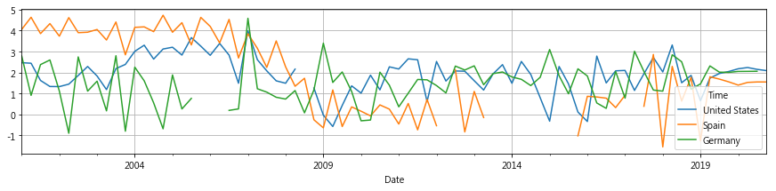

```python
OECDdata.loc[:,['United States','Spain','Germany']].plot(figsize=(15,3),grid='true')
```

我們可以看到圖上面有許多空白，接著我們要利用不同方式來處理缺失值

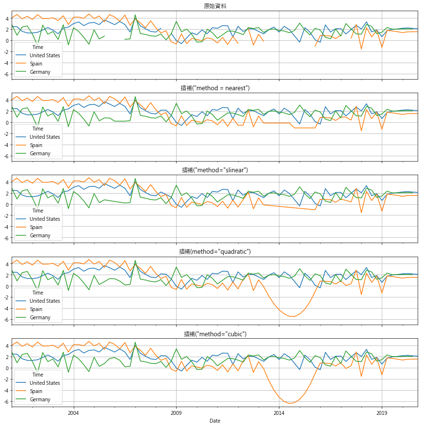

```python
#取OECDdata的['United States','Spain','Germany']這三個column變成新的資料表data
data = OECDdata[['United States','Spain','Germany']]

# dataframe 型態轉換 (將資料表內所有值變成數值，遇到error就轉換成NaN)
data.iloc[:,0] = pd.to_numeric(data.iloc[:,0], errors='coerce')
data.iloc[:,1] = pd.to_numeric(data.iloc[:,1], errors='coerce')
data.iloc[:,2] = pd.to_numeric(data.iloc[:,2], errors='coerce')

#製作一個5*1的畫板，五張圖彼此使用相同的x軸與y軸，整張圖的大小為(15,15)
fig1, axes = plt.subplots(5,1,sharex=True,sharey=True,figsize=(15,15))

#dataframe有.plot()這個方法可以製圖，利用ax指定圖的位置。 grid=True是開啟格線, title你懂的
data.plot(ax=axes[0],grid=True,title='原始資料')
#data.interpolate(method='xxxxxx')會先得到一個插補後的資料表
#我們再利用.plot畫圖 至於method的參數就字面上的意思 有興趣可以自己google
data.interpolate(method='nearest').plot(ax=axes[1],grid=True,title='插補("method = nearest")')
data.interpolate(method='slinear').plot(ax=axes[2],grid=True,title='插補("method="slinear")')
data.interpolate(method='quadratic').plot(ax=axes[3],grid=True,title='插補(method="quadratic")')
data.interpolate(method='cubic').plot(ax=axes[4],grid=True,title='插補("method="cubic")')
plt.show()
```

## 整份程式就會長差不多這樣

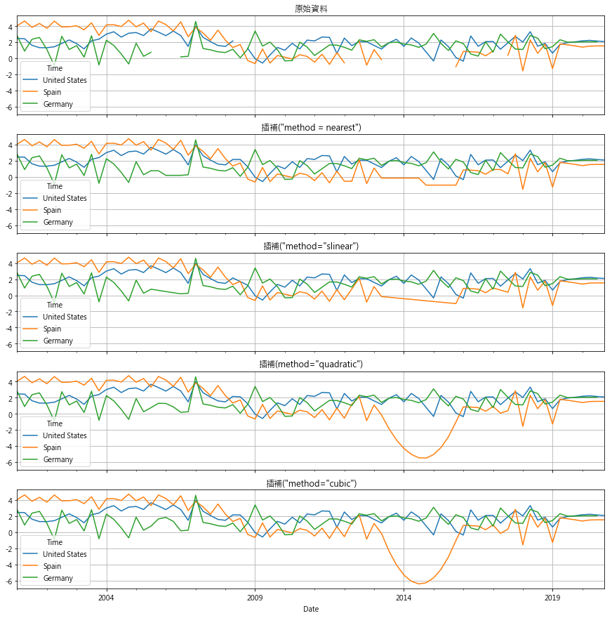

```python
import pandas as pd
import numpy as np
import matplotlib.pyplot as plt
#引入我們需要使用的套件

rawData = pd.read_excel('OECDoutlook2019.xls',sheet_name = 'OECD.Stat export',
                        skiprows = [0,1,2,3], header = 0)

rawData = rawData.T #將我們的資料轉置
rawData = rawData.drop(rawData.index[1:3])#將第一列和第二列刪除
rawData = rawData.drop(columns=[0]) #將第0行刪除
rawData = rawData.drop(columns=rawData.columns[-1]) #刪除最後一行的資料
rawData.columns = rawData.iloc[0,:]#將整列columns的名字換成第0列
rawData = rawData.drop(rawData.index[0])#刪除第0列


ii = 0
nan_list=[] #建立缺失值清單
for j in rawData.columns:
    #判斷每一個 column 裡的 element 是否不是 float，並存起來
    nan_list = nan_list+[i for i in rawData.iloc[:,ii] if type(i)!=float]
    #list可以用+法將兩個list合併
    ii=ii+1#每一個迴圈ii都加1，它的意義相當於是目前執行到第幾列


rawData = pd.read_excel('OECDoutlook2019.xls',sheet_name = 'OECD.Stat export',
                        skiprows = [0,1,2,3], header = 0, na_values=nan_list)
rawData = rawData.T #將我們的資料轉置
rawData = rawData.drop(rawData.index[1:3])#將第一列和第二列刪除
rawData = rawData.drop(columns=[0]) #將第0行刪除
rawData = rawData.drop(columns=rawData.columns[-1]) #刪除最後一行的資料
rawData.columns = rawData.iloc[0,:]#將整列columns的名字換成第0列
rawData = rawData.drop(rawData.index[0])#刪除第0列


ii =0
# 重新建立一個 column 命名為 Date 以字串 d 存入
rawData['Date']='d'
for x in rawData.index: # 以 rawData.index 作為迴圈空間
    rawData['Date'][ii] = x[-4:]+x[0:2] # 字串重新合併
    ii=ii+1
rawData.index = pd.to_datetime(rawData['Date'])
OECDdata = rawData
OECDdata = OECDdata.drop('Date',axis=1) # 刪除 column date



#取OECDdata的['United States','Spain','Germany']這三個column變成新的資料表data
data = OECDdata[['United States','Spain','Germany']]

# dataframe 型態轉換 (將資料表內所有值變成數值，遇到error就轉換成NaN)
data.iloc[:,0] = pd.to_numeric(data.iloc[:,0], errors='coerce')
data.iloc[:,1] = pd.to_numeric(data.iloc[:,1], errors='coerce')
data.iloc[:,2] = pd.to_numeric(data.iloc[:,2], errors='coerce')

#製作一個5*1的畫板，五張圖彼此使用相同的x軸與y軸，整張圖的大小為(15,15)
fig1, axes = plt.subplots(5,1,sharex=True,sharey=True,figsize=(15,15))

#dataframe有.plot()這個方法可以製圖，利用ax指定圖的位置。 grid=True是開啟格線, title你懂的
data.plot(ax=axes[0],grid=True,title='原始資料')
#data.interpolate(method='xxxxxx')會先得到一個插補後的資料表
#我們再利用.plot畫圖 至於method的參數就字面上的意思 有興趣可以自己google
data.interpolate(method='nearest').plot(ax=axes[1],grid=True,title='插補("method = nearest")')
data.interpolate(method='slinear').plot(ax=axes[2],grid=True,title='插補("method="slinear")')
data.interpolate(method='quadratic').plot(ax=axes[3],grid=True,title='插補(method="quadratic")')
data.interpolate(method='cubic').plot(ax=axes[4],grid=True,title='插補("method="cubic")')
plt.show()
```